# Project 1:Write a Data Science blog post

### Section 1 : Business Understanding

> In this project, I will be using the Boston AirBnB dataset taken from Kaggle. I will be using this information to predict the revenue of a small rental property in the Boston area. Through this project, I will answer the following questions:
> - What is the expected occupancy rate of a rental property in Boston based on a rental price?
> - What is the Average Daily Rate (expected revenue) of a rental property in the Boston area?
> - Try to determine if a small apartment or a small house is a better option for investment and future rental in the Bostor area. This analysis can be the foundation for a more sophisticated to predict rental income for a small investments in the Boston area.

### Section 2 : Data Understanding

> The initial dataset was taken from the 'listings.csv' file. This file contains 3,585 listed properties with 95 columns with many, many features for each property such as ratings, pictures, prices, and many more.

> In this analysis, I will reduce this dataset to only 14 columns to provide me the necessary information to answer previous questions. I developed this work using a classroom Jupyter notebook.

```python
#Here I imported necessary libraries, packages, set plots and dataset

import numpy as np
import pandas as pd
import matplotlib.pyplot as plt
from sklearn.linear_model import LinearRegression
from sklearn.model_selection import train_test_split
from sklearn.metrics import r2_score, mean_squared_error
import ImputingValues as t
import seaborn as sns
%matplotlib inline

df0 = pd.read_csv('./listings.csv')
df0.head()
```

|  | id | listing_url | scrape_id | last_scraped | name | summary | space | description | experiences_offered | neighborhood_overview | ... | review_scores_value | requires_license | license | jurisdiction_names | instant_bookable | cancellation_policy | require_guest_profile_picture | require_guest_phone_verification | calculated_host_listings_count | reviews_per_month |
| --- | --- | --- | --- | --- | --- | --- | --- | --- | --- | --- | --- | --- | --- | --- | --- | --- | --- | --- | --- | --- | --- |
| 0 | 12147973 | https://www.airbnb.com/rooms/12147973 | 20160906204935 | 2016-09-07 | Sunny Bungalow in the City | Cozy, sunny, family home. Master bedroom high... | The house has an open and cozy feel at the sam... | Cozy, sunny, family home. Master bedroom high... | none | Roslindale is quiet, convenient and friendly. ... | ... | NaN | f | NaN | NaN | f | moderate | f | f | 1 | NaN |
| 1 | 3075044 | https://www.airbnb.com/rooms/3075044 | 20160906204935 | 2016-09-07 | Charming room in pet friendly apt | Charming and quiet room in a second floor 1910... | Small but cozy and quite room with a full size... | Charming and quiet room in a second floor 1910... | none | The room is in Roslindale, a diverse and prima... | ... | 9.0 | f | NaN | NaN | t | moderate | f | f | 1 | 1.30 |
| 2 | 6976 | https://www.airbnb.com/rooms/6976 | 20160906204935 | 2016-09-07 | Mexican Folk Art Haven in Boston | Come stay with a friendly, middle-aged guy in ... | Come stay with a friendly, middle-aged guy in ... | Come stay with a friendly, middle-aged guy in ... | none | The LOCATION: Roslindale is a safe and diverse... | ... | 10.0 | f | NaN | NaN | f | moderate | t | f | 1 | 0.47 |
| 3 | 1436513 | https://www.airbnb.com/rooms/1436513 | 20160906204935 | 2016-09-07 | Spacious Sunny Bedroom Suite in Historic Home | Come experience the comforts of home away from... | Most places you find in Boston are small howev... | Come experience the comforts of home away from... | none | Roslindale is a lovely little neighborhood loc... | ... | 10.0 | f | NaN | NaN | f | moderate | f | f | 1 | 1.00 |
| 4 | 7651065 | https://www.airbnb.com/rooms/7651065 | 20160906204935 | 2016-09-07 | Come Home to Boston | My comfy, clean and relaxing home is one block... | Clean, attractive, private room, one block fro... | My comfy, clean and relaxing home is one block... | none | I love the proximity to downtown, the neighbor... | ... | 10.0 | f | NaN | NaN | f | flexible | f | f | 1 | 2.25 |

5 rows × 95 columns

```python
df1=df0.copy()
```

```python
df1.info()
```

```
<class 'pandas.core.frame.DataFrame'>
RangeIndex: 3585 entries, 0 to 3584
Data columns (total 95 columns):
id                                  3585 non-null int64
listing_url                         3585 non-null object
scrape_id                           3585 non-null int64
last_scraped                        3585 non-null object
name                                3585 non-null object
summary                             3442 non-null object
space                               2528 non-null object
description                         3585 non-null object
experiences_offered                 3585 non-null object
neighborhood_overview               2170 non-null object
notes                               1610 non-null object
transit                             2295 non-null object
access                              2096 non-null object
interaction                         2031 non-null object
house_rules                         2393 non-null object
thumbnail_url                       2986 non-null object
medium_url                          2986 non-null object
picture_url                         3585 non-null object
xl_picture_url                      2986 non-null object
host_id                             3585 non-null int64
host_url                            3585 non-null object
host_name                           3585 non-null object
host_since                          3585 non-null object
host_location                       3574 non-null object
host_about                          2276 non-null object
host_response_time                  3114 non-null object
host_response_rate                  3114 non-null object
host_acceptance_rate                3114 non-null object
host_is_superhost                   3585 non-null object
host_thumbnail_url                  3585 non-null object
host_picture_url                    3585 non-null object
host_neighbourhood                  3246 non-null object
host_listings_count                 3585 non-null int64
host_total_listings_count           3585 non-null int64
host_verifications                  3585 non-null object
host_has_profile_pic                3585 non-null object
host_identity_verified              3585 non-null object
```

[output cut: 45 more lines]

```
review_scores_checkin               2765 non-null float64
review_scores_communication         2767 non-null float64
review_scores_location              2763 non-null float64
review_scores_value                 2764 non-null float64
requires_license                    3585 non-null object
license                             0 non-null float64
jurisdiction_names                  0 non-null float64
instant_bookable                    3585 non-null object
cancellation_policy                 3585 non-null object
require_guest_profile_picture       3585 non-null object
require_guest_phone_verification    3585 non-null object
calculated_host_listings_count      3585 non-null int64
reviews_per_month                   2829 non-null float64
dtypes: float64(18), int64(15), object(62)
memory usage: 2.6+ MB
```

### Section 3 : Data preparation

> After reviewing the entire dataset, I was able to identify the columns that I will be using in my work.

> I will focus my analysis using the following 14 columns only: 1) - ID 2) - Neighbourhood 3) - Zipcode 4) - Property type 5) - Acommodate 6) - Bathrooms 7) - Bedrooms 8) - Price 9) - Security deposit 10) - Cleaning fee 11) - Availability 30 12) - Availability 60 13) - Availability 90 14) - Availability 365

> Below, I will start dropping unnecessary columns.

```python
df1.drop(df1.iloc[:, 1:38], inplace=True, axis=1)
```

```python
df1.info()
```

```
<class 'pandas.core.frame.DataFrame'>
RangeIndex: 3585 entries, 0 to 3584
Data columns (total 58 columns):
id                                  3585 non-null int64
neighbourhood                       3042 non-null object
neighbourhood_cleansed              3585 non-null object
neighbourhood_group_cleansed        0 non-null float64
city                                3583 non-null object
state                               3585 non-null object
zipcode                             3547 non-null object
market                              3571 non-null object
smart_location                      3585 non-null object
country_code                        3585 non-null object
country                             3585 non-null object
latitude                            3585 non-null float64
longitude                           3585 non-null float64
is_location_exact                   3585 non-null object
property_type                       3582 non-null object
room_type                           3585 non-null object
accommodates                        3585 non-null int64
bathrooms                           3571 non-null float64
bedrooms                            3575 non-null float64
beds                                3576 non-null float64
bed_type                            3585 non-null object
amenities                           3585 non-null object
square_feet                         56 non-null float64
price                               3585 non-null object
weekly_price                        892 non-null object
monthly_price                       888 non-null object
security_deposit                    1342 non-null object
cleaning_fee                        2478 non-null object
guests_included                     3585 non-null int64
extra_people                        3585 non-null object
minimum_nights                      3585 non-null int64
maximum_nights                      3585 non-null int64
calendar_updated                    3585 non-null object
has_availability                    0 non-null float64
availability_30                     3585 non-null int64
availability_60                     3585 non-null int64
availability_90                     3585 non-null int64
```

[output cut: 8 more lines]

```
review_scores_checkin               2765 non-null float64
review_scores_communication         2767 non-null float64
review_scores_location              2763 non-null float64
review_scores_value                 2764 non-null float64
requires_license                    3585 non-null object
license                             0 non-null float64
jurisdiction_names                  0 non-null float64
instant_bookable                    3585 non-null object
cancellation_policy                 3585 non-null object
require_guest_profile_picture       3585 non-null object
require_guest_phone_verification    3585 non-null object
calculated_host_listings_count      3585 non-null int64
reviews_per_month                   2829 non-null float64
dtypes: float64(18), int64(11), object(29)
memory usage: 1.6+ MB
```

```python
df1.drop(df1.iloc[:, 2:6], inplace=True, axis=1)
```

```python
df1.info()
```

```
<class 'pandas.core.frame.DataFrame'>
RangeIndex: 3585 entries, 0 to 3584
Data columns (total 54 columns):
id                                  3585 non-null int64
neighbourhood                       3042 non-null object
zipcode                             3547 non-null object
market                              3571 non-null object
smart_location                      3585 non-null object
country_code                        3585 non-null object
country                             3585 non-null object
latitude                            3585 non-null float64
longitude                           3585 non-null float64
is_location_exact                   3585 non-null object
property_type                       3582 non-null object
room_type                           3585 non-null object
accommodates                        3585 non-null int64
bathrooms                           3571 non-null float64
bedrooms                            3575 non-null float64
beds                                3576 non-null float64
bed_type                            3585 non-null object
amenities                           3585 non-null object
square_feet                         56 non-null float64
price                               3585 non-null object
weekly_price                        892 non-null object
monthly_price                       888 non-null object
security_deposit                    1342 non-null object
cleaning_fee                        2478 non-null object
guests_included                     3585 non-null int64
extra_people                        3585 non-null object
minimum_nights                      3585 non-null int64
maximum_nights                      3585 non-null int64
calendar_updated                    3585 non-null object
has_availability                    0 non-null float64
availability_30                     3585 non-null int64
availability_60                     3585 non-null int64
availability_90                     3585 non-null int64
availability_365                    3585 non-null int64
calendar_last_scraped               3585 non-null object
number_of_reviews                   3585 non-null int64
first_review                        2829 non-null object
last_review                         2829 non-null object
review_scores_rating                2772 non-null float64
review_scores_accuracy              2762 non-null float64
review_scores_cleanliness           2767 non-null float64
review_scores_checkin               2765 non-null float64
review_scores_communication         2767 non-null float64
review_scores_location              2763 non-null float64
review_scores_value                 2764 non-null float64
requires_license                    3585 non-null object
license                             0 non-null float64
jurisdiction_names                  0 non-null float64
instant_bookable                    3585 non-null object
cancellation_policy                 3585 non-null object
require_guest_profile_picture       3585 non-null object
require_guest_phone_verification    3585 non-null object
calculated_host_listings_count      3585 non-null int64
reviews_per_month                   2829 non-null float64
dtypes: float64(17), int64(11), object(26)
memory usage: 1.5+ MB
```

```python
df1.drop(df1.iloc[:, 3:10], inplace=True, axis=1)
```

```python
df1.info()
```

```
<class 'pandas.core.frame.DataFrame'>
RangeIndex: 3585 entries, 0 to 3584
Data columns (total 47 columns):
id                                  3585 non-null int64
neighbourhood                       3042 non-null object
zipcode                             3547 non-null object
property_type                       3582 non-null object
room_type                           3585 non-null object
accommodates                        3585 non-null int64
bathrooms                           3571 non-null float64
bedrooms                            3575 non-null float64
beds                                3576 non-null float64
bed_type                            3585 non-null object
amenities                           3585 non-null object
square_feet                         56 non-null float64
price                               3585 non-null object
weekly_price                        892 non-null object
monthly_price                       888 non-null object
security_deposit                    1342 non-null object
cleaning_fee                        2478 non-null object
guests_included                     3585 non-null int64
extra_people                        3585 non-null object
minimum_nights                      3585 non-null int64
maximum_nights                      3585 non-null int64
calendar_updated                    3585 non-null object
has_availability                    0 non-null float64
availability_30                     3585 non-null int64
availability_60                     3585 non-null int64
availability_90                     3585 non-null int64
availability_365                    3585 non-null int64
calendar_last_scraped               3585 non-null object
number_of_reviews                   3585 non-null int64
first_review                        2829 non-null object
last_review                         2829 non-null object
review_scores_rating                2772 non-null float64
review_scores_accuracy              2762 non-null float64
review_scores_cleanliness           2767 non-null float64
review_scores_checkin               2765 non-null float64
review_scores_communication         2767 non-null float64
review_scores_location              2763 non-null float64
review_scores_value                 2764 non-null float64
requires_license                    3585 non-null object
license                             0 non-null float64
jurisdiction_names                  0 non-null float64
instant_bookable                    3585 non-null object
cancellation_policy                 3585 non-null object
require_guest_profile_picture       3585 non-null object
require_guest_phone_verification    3585 non-null object
calculated_host_listings_count      3585 non-null int64
reviews_per_month                   2829 non-null float64
dtypes: float64(15), int64(11), object(21)
memory usage: 1.3+ MB
```

```python
del df1['room_type']
```

```python
df1.info()
```

```
<class 'pandas.core.frame.DataFrame'>
RangeIndex: 3585 entries, 0 to 3584
Data columns (total 46 columns):
id                                  3585 non-null int64
neighbourhood                       3042 non-null object
zipcode                             3547 non-null object
property_type                       3582 non-null object
accommodates                        3585 non-null int64
bathrooms                           3571 non-null float64
bedrooms                            3575 non-null float64
beds                                3576 non-null float64
bed_type                            3585 non-null object
amenities                           3585 non-null object
square_feet                         56 non-null float64
price                               3585 non-null object
weekly_price                        892 non-null object
monthly_price                       888 non-null object
security_deposit                    1342 non-null object
cleaning_fee                        2478 non-null object
guests_included                     3585 non-null int64
extra_people                        3585 non-null object
minimum_nights                      3585 non-null int64
maximum_nights                      3585 non-null int64
calendar_updated                    3585 non-null object
has_availability                    0 non-null float64
availability_30                     3585 non-null int64
availability_60                     3585 non-null int64
availability_90                     3585 non-null int64
availability_365                    3585 non-null int64
calendar_last_scraped               3585 non-null object
number_of_reviews                   3585 non-null int64
first_review                        2829 non-null object
last_review                         2829 non-null object
review_scores_rating                2772 non-null float64
review_scores_accuracy              2762 non-null float64
review_scores_cleanliness           2767 non-null float64
review_scores_checkin               2765 non-null float64
review_scores_communication         2767 non-null float64
review_scores_location              2763 non-null float64
review_scores_value                 2764 non-null float64
requires_license                    3585 non-null object
license                             0 non-null float64
jurisdiction_names                  0 non-null float64
instant_bookable                    3585 non-null object
cancellation_policy                 3585 non-null object
require_guest_profile_picture       3585 non-null object
require_guest_phone_verification    3585 non-null object
calculated_host_listings_count      3585 non-null int64
reviews_per_month                   2829 non-null float64
dtypes: float64(15), int64(11), object(20)
memory usage: 1.3+ MB
```

```python
df1.drop(df1.iloc[:, 7:11], inplace=True, axis=1)
```

```python
df1.info()
```

```
<class 'pandas.core.frame.DataFrame'>
RangeIndex: 3585 entries, 0 to 3584
Data columns (total 42 columns):
id                                  3585 non-null int64
neighbourhood                       3042 non-null object
zipcode                             3547 non-null object
property_type                       3582 non-null object
accommodates                        3585 non-null int64
bathrooms                           3571 non-null float64
bedrooms                            3575 non-null float64
price                               3585 non-null object
weekly_price                        892 non-null object
monthly_price                       888 non-null object
security_deposit                    1342 non-null object
cleaning_fee                        2478 non-null object
guests_included                     3585 non-null int64
extra_people                        3585 non-null object
minimum_nights                      3585 non-null int64
maximum_nights                      3585 non-null int64
calendar_updated                    3585 non-null object
has_availability                    0 non-null float64
availability_30                     3585 non-null int64
availability_60                     3585 non-null int64
availability_90                     3585 non-null int64
availability_365                    3585 non-null int64
calendar_last_scraped               3585 non-null object
number_of_reviews                   3585 non-null int64
first_review                        2829 non-null object
last_review                         2829 non-null object
review_scores_rating                2772 non-null float64
review_scores_accuracy              2762 non-null float64
review_scores_cleanliness           2767 non-null float64
review_scores_checkin               2765 non-null float64
review_scores_communication         2767 non-null float64
review_scores_location              2763 non-null float64
review_scores_value                 2764 non-null float64
requires_license                    3585 non-null object
license                             0 non-null float64
jurisdiction_names                  0 non-null float64
instant_bookable                    3585 non-null object
cancellation_policy                 3585 non-null object
require_guest_profile_picture       3585 non-null object
require_guest_phone_verification    3585 non-null object
calculated_host_listings_count      3585 non-null int64
reviews_per_month                   2829 non-null float64
dtypes: float64(13), int64(11), object(18)
memory usage: 1.1+ MB
```

```python
df1.drop(df1.iloc[:, 12:18], inplace=True, axis=1)
```

```python
df1.info()
```

```
<class 'pandas.core.frame.DataFrame'>
RangeIndex: 3585 entries, 0 to 3584
Data columns (total 36 columns):
id                                  3585 non-null int64
neighbourhood                       3042 non-null object
zipcode                             3547 non-null object
property_type                       3582 non-null object
accommodates                        3585 non-null int64
bathrooms                           3571 non-null float64
bedrooms                            3575 non-null float64
price                               3585 non-null object
weekly_price                        892 non-null object
monthly_price                       888 non-null object
security_deposit                    1342 non-null object
cleaning_fee                        2478 non-null object
availability_30                     3585 non-null int64
availability_60                     3585 non-null int64
availability_90                     3585 non-null int64
availability_365                    3585 non-null int64
calendar_last_scraped               3585 non-null object
number_of_reviews                   3585 non-null int64
first_review                        2829 non-null object
last_review                         2829 non-null object
review_scores_rating                2772 non-null float64
review_scores_accuracy              2762 non-null float64
review_scores_cleanliness           2767 non-null float64
review_scores_checkin               2765 non-null float64
review_scores_communication         2767 non-null float64
review_scores_location              2763 non-null float64
review_scores_value                 2764 non-null float64
requires_license                    3585 non-null object
license                             0 non-null float64
jurisdiction_names                  0 non-null float64
instant_bookable                    3585 non-null object
cancellation_policy                 3585 non-null object
require_guest_profile_picture       3585 non-null object
require_guest_phone_verification    3585 non-null object
calculated_host_listings_count      3585 non-null int64
reviews_per_month                   2829 non-null float64
dtypes: float64(12), int64(8), object(16)
memory usage: 1008.4+ KB
```

```python
df1.drop(df1.iloc[:, 16:36], inplace=True, axis=1)
```

```python
df1.info()
```

```
<class 'pandas.core.frame.DataFrame'>
RangeIndex: 3585 entries, 0 to 3584
Data columns (total 16 columns):
id                  3585 non-null int64
neighbourhood       3042 non-null object
zipcode             3547 non-null object
property_type       3582 non-null object
accommodates        3585 non-null int64
bathrooms           3571 non-null float64
bedrooms            3575 non-null float64
price               3585 non-null object
weekly_price        892 non-null object
monthly_price       888 non-null object
security_deposit    1342 non-null object
cleaning_fee        2478 non-null object
availability_30     3585 non-null int64
availability_60     3585 non-null int64
availability_90     3585 non-null int64
availability_365    3585 non-null int64
dtypes: float64(2), int64(6), object(8)
memory usage: 448.2+ KB
```

```python
del df1['weekly_price']
```

```python
del df1['monthly_price']
```

```python
df1.info()
```

```
<class 'pandas.core.frame.DataFrame'>
RangeIndex: 3585 entries, 0 to 3584
Data columns (total 14 columns):
id                  3585 non-null int64
neighbourhood       3042 non-null object
zipcode             3547 non-null object
property_type       3582 non-null object
accommodates        3585 non-null int64
bathrooms           3571 non-null float64
bedrooms            3575 non-null float64
price               3585 non-null object
security_deposit    1342 non-null object
cleaning_fee        2478 non-null object
availability_30     3585 non-null int64
availability_60     3585 non-null int64
availability_90     3585 non-null int64
availability_365    3585 non-null int64
dtypes: float64(2), int64(6), object(6)
memory usage: 392.2+ KB
```

> Now that I have reduced the number of columns to 14 desired columns, I will start to explore, clean up, organize and eliminate missing data

> Eliminating rows and columns with missing data. I decided to eliminate this data because I am trying to predict a rental income. Replacing these values with average data will not help with my analysis.

```python
df1.head()
```

|  | id | neighbourhood | zipcode | property_type | accommodates | bathrooms | bedrooms | price | security_deposit | cleaning_fee | availability_30 | availability_60 | availability_90 | availability_365 |
| --- | --- | --- | --- | --- | --- | --- | --- | --- | --- | --- | --- | --- | --- | --- |
| 0 | 12147973 | Roslindale | 02131 | House | 4 | 1.5 | 2.0 | $250.00 | NaN | $35.00 | 0 | 0 | 0 | 0 |
| 1 | 3075044 | Roslindale | 02131 | Apartment | 2 | 1.0 | 1.0 | $65.00 | $95.00 | $10.00 | 26 | 54 | 84 | 359 |
| 2 | 6976 | Roslindale | 02131 | Apartment | 2 | 1.0 | 1.0 | $65.00 | NaN | NaN | 19 | 46 | 61 | 319 |
| 3 | 1436513 | NaN | NaN | House | 4 | 1.0 | 1.0 | $75.00 | $100.00 | $50.00 | 6 | 16 | 26 | 98 |
| 4 | 7651065 | Roslindale | 02131 | House | 2 | 1.5 | 1.0 | $79.00 | NaN | $15.00 | 13 | 34 | 59 | 334 |

```python
df2=df1.copy()
```

```python
df2[df2.neighbourhood.isnull()]
```

|  | id | neighbourhood | zipcode | property_type | accommodates | bathrooms | bedrooms | price | security_deposit | cleaning_fee | availability_30 | availability_60 | availability_90 | availability_365 |
| --- | --- | --- | --- | --- | --- | --- | --- | --- | --- | --- | --- | --- | --- | --- |
| 3 | 1436513 | NaN | NaN | House | 4 | 1.0 | 1.0 | $75.00 | $100.00 | $50.00 | 6 | 16 | 26 | 98 |
| 6 | 5706985 | NaN | 02131 | Apartment | 3 | 1.0 | 1.0 | $100.00 | NaN | NaN | 22 | 39 | 69 | 344 |
| 19 | 7252607 | NaN | 02131 | House | 2 | 1.0 | 1.0 | $49.00 | NaN | NaN | 0 | 0 | 0 | 262 |
| 23 | 6400432 | NaN | 02131 | House | 8 | 1.0 | 3.0 | $150.00 | $150.00 | $100.00 | 0 | 0 | 0 | 0 |
| 36 | 10116095 | NaN | 02131 | Apartment | 2 | 1.0 | 1.0 | $115.00 | $200.00 | $35.00 | 19 | 46 | 76 | 351 |
| 54 | 12994227 | NaN | 02131 | Condominium | 2 | 1.0 | 1.0 | $65.00 | NaN | $20.00 | 6 | 10 | 10 | 259 |
| 64 | 6248970 | NaN | 02130 | Apartment | 1 | 1.0 | 1.0 | $65.00 | NaN | NaN | 7 | 13 | 43 | 43 |
| 88 | 12855396 | NaN | 02130 | House | 1 | 1.0 | 1.0 | $57.00 | NaN | NaN | 6 | 36 | 66 | 341 |
| 94 | 2538536 | NaN | NaN | Apartment | 3 | 1.0 | 1.0 | $149.00 | NaN | $50.00 | 0 | 28 | 58 | 333 |
| 150 | 6059968 | NaN | 02130 | Apartment | 2 | 1.0 | 1.0 | $100.00 | $500.00 | $50.00 | 5 | 33 | 63 | 338 |
| 162 | 13512551 | NaN | NaN | House | 6 | 2.5 | 4.0 | $199.00 | NaN | NaN | 0 | 5 | 35 | 35 |
| 176 | 14933380 | NaN | 02130 | Apartment | 1 | 1.0 | 1.0 | $49.00 | NaN | NaN | 25 | 51 | 81 | 81 |
| 188 | 3977877 | NaN | 02130 | Apartment | 2 | 1.0 | 1.0 | $110.00 | $100.00 | $50.00 | 0 | 0 | 0 | 0 |
| 216 | 7348110 | NaN | 02120 | Apartment | 4 | 1.0 | 2.0 | $300.00 | $100.00 | $50.00 | 29 | 59 | 89 | 364 |
| 222 | 11946029 | NaN | 02130 | Apartment | 2 | 1.0 | 1.0 | $100.00 | NaN | NaN | 0 | 4 | 34 | 309 |
| 225 | 9676551 | NaN | 02130 | Apartment | 2 | 1.0 | 1.0 | $76.00 | NaN | $5.00 | 3 | 13 | 39 | 314 |
| 226 | 12789527 | NaN | NaN | Apartment | 2 | 1.0 | 1.0 | $100.00 | $500.00 | $9.00 | 10 | 40 | 70 | 70 |
| 231 | 13344433 | NaN | 02130 | House | 3 | 1.0 | 2.0 | $170.00 | $250.00 | NaN | 14 | 31 | 39 | 39 |
| 244 | 12593295 | NaN | 02130 | Apartment | 2 | 1.0 | 1.0 | $68.00 | NaN | NaN | 2 | 6 | 36 | 311 |
| 255 | 13623390 | NaN | 02130 | Apartment | 2 | 1.0 | 1.0 | $100.00 | NaN | NaN | 0 | 2 | 4 | 252 |
| 257 | 10883063 | NaN | 02130 | House | 3 | 1.0 | 1.0 | $95.00 | NaN | $35.00 | 6 | 25 | 39 | 39 |
| 261 | 11739985 | NaN | 02130 | House | 5 | 1.0 | 2.0 | $189.00 | NaN | $30.00 | 7 | 36 | 66 | 341 |
| 263 | 7693009 | NaN | 02130 | Apartment | 2 | 1.0 | 1.0 | $55.00 | NaN | $55.00 | 14 | 38 | 68 | 343 |
| 267 | 14428514 | NaN | 02130 | Apartment | 1 | 1.0 | 1.0 | $22.00 | NaN | NaN | 23 | 53 | 83 | 358 |
| 289 | 8067585 | NaN | 02130 | Apartment | 2 | 1.0 | 1.0 | $83.00 | NaN | NaN | 0 | 20 | 50 | 50 |
| 296 | 3905508 | NaN | 02131 | House | 2 | 1.0 | 1.0 | $130.00 | $300.00 | $35.00 | 4 | 23 | 41 | 285 |
| 298 | 14566386 | NaN | 02130 | Apartment | 3 | 1.0 | 2.0 | $160.00 | $300.00 | $50.00 | 0 | 0 | 15 | 290 |
| 300 | 14469677 | NaN | 02130 | House | 4 | 1.0 | 1.0 | $77.00 | NaN | $10.00 | 3 | 29 | 49 | 128 |
| 302 | 12736777 | NaN | 02130 | Townhouse | 2 | 1.5 | 1.0 | $200.00 | NaN | NaN | 0 | 0 | 0 | 217 |
| 307 | 14308511 | NaN | 02130 | Apartment | 3 | 1.0 | 1.0 | $72.00 | $95.00 | $15.00 | 9 | 39 | 69 | 344 |
| ... | ... | ... | ... | ... | ... | ... | ... | ... | ... | ... | ... | ... | ... | ... |
| 3420 | 11896394 | NaN | 02134 | Apartment | 2 | 1.0 | 1.0 | $105.00 | $100.00 | $50.00 | 0 | 12 | 14 | 262 |
| 3438 | 9110708 | NaN | 02134 | Apartment | 3 | 1.0 | 1.0 | $109.00 | NaN | NaN | 0 | 0 | 0 | 0 |
| 3467 | 12752442 | NaN | 02134 | Apartment | 2 | 1.0 | 1.0 | $127.00 | NaN | $20.00 | 5 | 22 | 45 | 45 |
| 3468 | 12736032 | NaN | 02134 | Apartment | 2 | 1.0 | 1.0 | $11.00 | NaN | NaN | 0 | 0 | 0 | 2 |
| 3474 | 12735111 | NaN | 02135 | House | 1 | 1.0 | 0.0 | $55.00 | NaN | NaN | 30 | 58 | 88 | 363 |
| 3477 | 14340601 | NaN | NaN | Apartment | 2 | 1.0 | 1.0 | $149.00 | NaN | $59.00 | 10 | 20 | 38 | 156 |
| 3488 | 14454943 | NaN | 02134 | Apartment | 2 | 1.0 | 1.0 | $65.00 | $100.00 | $30.00 | 10 | 40 | 70 | 345 |
| 3508 | 8882195 | NaN | 02134 | Apartment | 2 | 1.0 | 1.0 | $139.00 | $400.00 | $80.00 | 15 | 35 | 65 | 111 |
| 3515 | 9570618 | NaN | 02134 | Condominium | 3 | 1.0 | 1.0 | $120.00 | NaN | NaN | 27 | 57 | 87 | 362 |
| 3516 | 3609536 | NaN | 02163 | Apartment | 2 | 1.0 | 1.0 | $70.00 | NaN | NaN | 0 | 0 | 0 | 0 |
| 3518 | 2672058 | NaN | 02134 | Apartment | 2 | 1.0 | 1.0 | $85.00 | $100.00 | NaN | 3 | 3 | 3 | 3 |
| 3531 | 7462268 | NaN | 02134 | House | 2 | 2.0 | 1.0 | $75.00 | $100.00 | $35.00 | 0 | 11 | 15 | 290 |
| 3537 | 14503389 | NaN | 02138 | House | 1 | 1.0 | 1.0 | $85.00 | NaN | NaN | 2 | 18 | 42 | 312 |
| 3539 | 4332035 | NaN | 02446 | Apartment | 3 | 1.0 | 1.0 | $272.00 | NaN | $100.00 | 6 | 36 | 66 | 124 |
| 3547 | 14848154 | NaN | 02145 | Apartment | 3 | 1.0 | 1.0 | $88.00 | $95.00 | NaN | 28 | 55 | 85 | 360 |
| 3553 | 14874204 | NaN | 02143 | Apartment | 2 | 1.0 | 1.0 | $69.00 | $95.00 | NaN | 25 | 55 | 85 | 360 |
| 3554 | 14533848 | NaN | 02446 | House | 4 | 1.0 | 1.0 | $125.00 | NaN | $25.00 | 0 | 0 | 0 | 5 |
| 3556 | 14849141 | NaN | 02143 | Apartment | 2 | 1.0 | 1.0 | $69.00 | NaN | NaN | 26 | 56 | 86 | 361 |
| 3557 | 14604429 | NaN | NaN | Apartment | 2 | 1.0 | 1.0 | $60.00 | NaN | $20.00 | 7 | 7 | 7 | 272 |
| 3558 | 14592644 | NaN | 02139 | Apartment | 4 | 1.0 | 2.0 | $195.00 | $200.00 | $130.00 | 20 | 45 | 75 | 137 |
| 3559 | 12915510 | NaN | 02129 | Boat | 7 | 1.0 | 1.0 | $229.00 | $500.00 | $100.00 | 30 | 60 | 90 | 365 |
| 3561 | 14823430 | NaN | NaN | Loft | 2 | 1.0 | 1.0 | $72.00 | NaN | NaN | 28 | 58 | 80 | 345 |
| 3562 | 14881840 | NaN | 02215 | Apartment | 2 | 1.0 | 1.0 | $179.00 | NaN | NaN | 29 | 59 | 89 | 364 |
| 3564 | 14576706 | NaN | 02143 | Apartment | 2 | 1.0 | 1.0 | $75.00 | $95.00 | NaN | 23 | 53 | 83 | 358 |
| 3565 | 14335003 | NaN | 02138 | Apartment | 4 | 1.0 | 1.0 | $146.00 | NaN | NaN | 0 | 0 | 0 | 0 |
| 3568 | 14574800 | NaN | 02143 | Apartment | 2 | 1.0 | 1.0 | $69.00 | $95.00 | NaN | 25 | 55 | 85 | 360 |
| 3569 | 14426586 | NaN | 02145 | Apartment | 4 | 1.0 | 1.0 | $200.00 | NaN | NaN | 29 | 59 | 89 | 364 |
| 3578 | 14536322 | NaN | 02138 | House | 1 | 1.0 | 1.0 | $85.00 | NaN | NaN | 4 | 16 | 44 | 315 |
| 3581 | 14844274 | NaN | 02446 | Apartment | 2 | 1.0 | 1.0 | $150.00 | $100.00 | $15.00 | 29 | 59 | 89 | 364 |
| 3582 | 14585486 | NaN | 02141 | Apartment | 4 | 1.0 | 1.0 | $198.00 | NaN | NaN | 0 | 15 | 40 | 40 |

543 rows × 14 columns

```python
df2[df2.bathrooms.isnull()]
```

|  | id | neighbourhood | zipcode | property_type | accommodates | bathrooms | bedrooms | price | security_deposit | cleaning_fee | availability_30 | availability_60 | availability_90 | availability_365 |
| --- | --- | --- | --- | --- | --- | --- | --- | --- | --- | --- | --- | --- | --- | --- |
| 103 | 777903 | Jamaica Plain | 02130 | House | 2 | NaN | 1.0 | $85.00 | NaN | NaN | 26 | 56 | 86 | 361 |
| 630 | 822063 | North End | 02113 | Apartment | 1 | NaN | 1.0 | $35.00 | $1,000.00 | NaN | 3 | 3 | 3 | 4 |
| 755 | 1426754 | North End | 02108 | Apartment | 2 | NaN | 1.0 | $99.00 | $300.00 | $75.00 | 0 | 20 | 46 | 300 |
| 800 | 276450 | Roxbury | 02118 | Apartment | 4 | NaN | 1.0 | $167.00 | $500.00 | $100.00 | 17 | 33 | 53 | 328 |
| 820 | 12627225 | NaN | 02125 | Bed & Breakfast | 2 | NaN | 1.0 | $60.00 | NaN | $15.00 | 29 | 59 | 89 | 364 |
| 825 | 12857811 | NaN | 02125 | House | 2 | NaN | 1.0 | $60.00 | NaN | $15.00 | 27 | 57 | 87 | 362 |
| 888 | 658029 | Roxbury | 02118 | Apartment | 4 | NaN | 1.0 | $163.00 | $500.00 | $100.00 | 4 | 16 | 39 | 284 |
| 910 | 12796808 | NaN | 02119 | Apartment | 1 | NaN | 1.0 | $53.00 | NaN | NaN | 29 | 59 | 89 | 364 |
| 989 | 225224 | South End | 02116 | House | 1 | NaN | 1.0 | $98.00 | NaN | $10.00 | 11 | 28 | 54 | 329 |
| 1120 | 22354 | South End | 02116 | Bed & Breakfast | 1 | NaN | 1.0 | $135.00 | NaN | $10.00 | 6 | 34 | 61 | 336 |
| 2196 | 67946 | Fenway/Kenmore | 02115 | Apartment | 3 | NaN | 1.0 | $249.00 | NaN | $150.00 | 29 | 59 | 89 | 364 |
| 2201 | 25142 | Fenway/Kenmore | 02215 | Apartment | 4 | NaN | 2.0 | $349.00 | NaN | $150.00 | 29 | 59 | 89 | 364 |
| 2785 | 1391215 | Dorchester | 02122 | House | 2 | NaN | 1.0 | $50.00 | $100.00 | $15.00 | 13 | 43 | 73 | 342 |
| 2819 | 9239190 | Dorchester | 02124 | House | 2 | NaN | 1.0 | $57.00 | NaN | NaN | 17 | 47 | 77 | 352 |

```python
df2=df2.dropna(subset=['bathrooms'])
```

```python
df2[df2.bathrooms.isnull()]
```

|  | id | neighbourhood | zipcode | property_type | accommodates | bathrooms | bedrooms | price | security_deposit | cleaning_fee | availability_30 | availability_60 | availability_90 | availability_365 |
| --- | --- | --- | --- | --- | --- | --- | --- | --- | --- | --- | --- | --- | --- | --- |

```python
df2[df2.bedrooms.isnull()]
```

|  | id | neighbourhood | zipcode | property_type | accommodates | bathrooms | bedrooms | price | security_deposit | cleaning_fee | availability_30 | availability_60 | availability_90 | availability_365 |
| --- | --- | --- | --- | --- | --- | --- | --- | --- | --- | --- | --- | --- | --- | --- |
| 918 | 1077105 | South End | 02118 | Apartment | 2 | 1.0 | NaN | $176.00 | NaN | NaN | 0 | 0 | 0 | 248 |
| 920 | 9765 | South End | 02118 | Apartment | 2 | 1.0 | NaN | $229.00 | NaN | $75.00 | 27 | 57 | 87 | 362 |
| 924 | 1044307 | South End | 02118 | Apartment | 2 | 1.0 | NaN | $275.00 | NaN | NaN | 27 | 57 | 87 | 362 |
| 1095 | 1119740 | South End | 02118 | Apartment | 2 | 1.0 | NaN | $186.00 | NaN | NaN | 24 | 54 | 82 | 357 |
| 1117 | 1071144 | South End | 02118 | Apartment | 2 | 1.0 | NaN | $269.00 | NaN | NaN | 24 | 54 | 82 | 357 |
| 1132 | 22208 | South End | 02118 | Apartment | 2 | 1.0 | NaN | $225.00 | NaN | NaN | 24 | 54 | 82 | 357 |
| 1251 | 9824 | Back Bay | 02115 | Apartment | 2 | 1.0 | NaN | $209.00 | NaN | NaN | 10 | 29 | 48 | 323 |
| 1366 | 1372816 | Back Bay | 02115 | Apartment | 2 | 1.0 | NaN | $209.00 | NaN | NaN | 11 | 31 | 53 | 328 |
| 1419 | 754845 | Back Bay | 02115 | Apartment | 2 | 1.0 | NaN | $209.00 | NaN | NaN | 8 | 28 | 47 | 322 |
| 1959 | 23619 | Beacon Hill | 02108 | Apartment | 2 | 1.0 | NaN | $175.00 | NaN | $50.00 | 2 | 8 | 8 | 252 |

```python
df2=df2.dropna(subset=['bedrooms'])
```

```python
df2[df2.bedrooms.isnull()]
```

|  | id | neighbourhood | zipcode | property_type | accommodates | bathrooms | bedrooms | price | security_deposit | cleaning_fee | availability_30 | availability_60 | availability_90 | availability_365 |
| --- | --- | --- | --- | --- | --- | --- | --- | --- | --- | --- | --- | --- | --- | --- |

```python
df2[df2.property_type.isnull()]
```

|  | id | neighbourhood | zipcode | property_type | accommodates | bathrooms | bedrooms | price | security_deposit | cleaning_fee | availability_30 | availability_60 | availability_90 | availability_365 |
| --- | --- | --- | --- | --- | --- | --- | --- | --- | --- | --- | --- | --- | --- | --- |
| 1321 | 7731797 | Back Bay | 02116 | NaN | 2 | 1.0 | 0.0 | $199.00 | $300.00 | $75.00 | 16 | 32 | 59 | 105 |
| 2061 | 14122467 | Downtown Crossing | 02110 | NaN | 2 | 1.0 | 1.0 | $190.00 | NaN | NaN | 0 | 0 | 0 | 0 |
| 3393 | 10758 | Allston-Brighton | 02134 | NaN | 1 | 1.0 | 1.0 | $115.00 | NaN | NaN | 3 | 13 | 43 | 43 |

```python
df2=df2.dropna(subset=['property_type'])
```

```python
df2.info()
```

```
<class 'pandas.core.frame.DataFrame'>
Int64Index: 3558 entries, 0 to 3584
Data columns (total 14 columns):
id                  3558 non-null int64
neighbourhood       3018 non-null object
zipcode             3520 non-null object
property_type       3558 non-null object
accommodates        3558 non-null int64
bathrooms           3558 non-null float64
bedrooms            3558 non-null float64
price               3558 non-null object
security_deposit    1336 non-null object
cleaning_fee        2465 non-null object
availability_30     3558 non-null int64
availability_60     3558 non-null int64
availability_90     3558 non-null int64
availability_365    3558 non-null int64
dtypes: float64(2), int64(6), object(6)
memory usage: 417.0+ KB
```

```python
df2[df2.cleaning_fee.isnull()]
```

|  | id | neighbourhood | zipcode | property_type | accommodates | bathrooms | bedrooms | price | security_deposit | cleaning_fee | availability_30 | availability_60 | availability_90 | availability_365 |
| --- | --- | --- | --- | --- | --- | --- | --- | --- | --- | --- | --- | --- | --- | --- |
| 2 | 6976 | Roslindale | 02131 | Apartment | 2 | 1.0 | 1.0 | $65.00 | NaN | NaN | 19 | 46 | 61 | 319 |
| 6 | 5706985 | NaN | 02131 | Apartment | 3 | 1.0 | 1.0 | $100.00 | NaN | NaN | 22 | 39 | 69 | 344 |
| 8 | 753446 | Roslindale | 02131 | Condominium | 2 | 1.0 | 1.0 | $58.00 | NaN | NaN | 12 | 42 | 72 | 347 |
| 15 | 225979 | Roslindale | 02131 | Apartment | 1 | 0.0 | 1.0 | $60.00 | NaN | NaN | 4 | 34 | 64 | 339 |
| 18 | 7482195 | Roslindale | 02131 | House | 1 | 1.0 | 1.0 | $49.00 | NaN | NaN | 0 | 0 | 20 | 295 |
| 19 | 7252607 | NaN | 02131 | House | 2 | 1.0 | 1.0 | $49.00 | NaN | NaN | 0 | 0 | 0 | 262 |
| 20 | 2583074 | Roslindale | 02131 | Villa | 1 | 2.5 | 1.0 | $40.00 | NaN | NaN | 6 | 27 | 57 | 332 |
| 22 | 225834 | Roslindale | 02131 | Apartment | 2 | 0.0 | 1.0 | $70.00 | NaN | NaN | 0 | 0 | 24 | 299 |
| 26 | 879929 | Roslindale | 02131 | Apartment | 2 | 1.0 | 1.0 | $90.00 | NaN | NaN | 0 | 0 | 0 | 122 |
| 28 | 321328 | Roslindale | 02131 | Apartment | 2 | 1.0 | 1.0 | $100.00 | NaN | NaN | 21 | 51 | 81 | 356 |
| 30 | 6513924 | Roslindale | 02131 | Condominium | 1 | 1.0 | 1.0 | $55.00 | NaN | NaN | 0 | 0 | 0 | 129 |
| 32 | 14690527 | Roslindale | 02131 | Apartment | 4 | 1.0 | 1.0 | $150.00 | NaN | NaN | 0 | 0 | 3 | 17 |
| 33 | 7086825 | Roslindale | 02131 | House | 1 | 1.0 | 1.0 | $49.00 | NaN | NaN | 0 | 20 | 50 | 325 |
| 34 | 1861070 | Roslindale | 02131 | House | 1 | 1.5 | 1.0 | $75.00 | NaN | NaN | 27 | 57 | 87 | 362 |
| 42 | 1936861 | Roslindale | 02131 | Apartment | 1 | 1.0 | 1.0 | $60.00 | NaN | NaN | 20 | 50 | 80 | 355 |
| 43 | 4461111 | Roslindale | 02131 | House | 1 | 1.5 | 1.0 | $45.00 | NaN | NaN | 6 | 6 | 6 | 254 |
| 45 | 13937181 | Roslindale | 02131 | House | 2 | 2.0 | 1.0 | $45.00 | NaN | NaN | 2 | 28 | 53 | 133 |
| 48 | 8473851 | Roslindale | 02131 | House | 2 | 2.0 | 1.0 | $50.00 | NaN | NaN | 11 | 41 | 71 | 161 |
| 49 | 3575220 | Roslindale | 02131 | House | 1 | 2.5 | 1.0 | $45.00 | NaN | NaN | 0 | 0 | 0 | 260 |
| 50 | 1591827 | Roslindale | 02131 | House | 2 | 1.0 | 1.0 | $60.00 | NaN | NaN | 0 | 0 | 0 | 248 |
| 58 | 2384581 | Jamaica Plain | 02130 | House | 2 | 1.0 | 1.0 | $95.00 | NaN | NaN | 30 | 60 | 90 | 365 |
| 59 | 735970 | Jamaica Plain | 02130 | Bed & Breakfast | 2 | 1.0 | 1.0 | $55.00 | NaN | NaN | 0 | 0 | 0 | 0 |
| 60 | 4262255 | Jamaica Plain | 02130 | Apartment | 2 | 1.0 | 1.0 | $80.00 | NaN | NaN | 0 | 8 | 26 | 301 |
| 61 | 4000384 | Jamaica Plain | 02119 | House | 2 | 1.0 | 1.0 | $120.00 | NaN | NaN | 7 | 17 | 47 | 109 |
| 62 | 6693305 | Jamaica Plain | 02130 | Apartment | 2 | 1.0 | 1.0 | $65.00 | NaN | NaN | 0 | 0 | 0 | 0 |
| 63 | 6730758 | Jamaica Plain | 02130 | Apartment | 4 | 1.0 | 1.0 | $100.00 | NaN | NaN | 1 | 3 | 3 | 23 |
| 64 | 6248970 | NaN | 02130 | Apartment | 1 | 1.0 | 1.0 | $65.00 | NaN | NaN | 7 | 13 | 43 | 43 |
| 65 | 12806707 | Jamaica Plain | 02130 | House | 1 | 1.0 | 1.0 | $60.00 | NaN | NaN | 5 | 35 | 65 | 340 |
| 66 | 14246616 | Jamaica Plain | 02130 | Apartment | 2 | 1.0 | 1.0 | $63.00 | NaN | NaN | 0 | 0 | 0 | 0 |
| 67 | 3703674 | Jamaica Plain | 02130 | Townhouse | 2 | 1.0 | 1.0 | $75.00 | $200.00 | NaN | 0 | 0 | 0 | 250 |
| ... | ... | ... | ... | ... | ... | ... | ... | ... | ... | ... | ... | ... | ... | ... |
| 3515 | 9570618 | NaN | 02134 | Condominium | 3 | 1.0 | 1.0 | $120.00 | NaN | NaN | 27 | 57 | 87 | 362 |
| 3516 | 3609536 | NaN | 02163 | Apartment | 2 | 1.0 | 1.0 | $70.00 | NaN | NaN | 0 | 0 | 0 | 0 |
| 3517 | 9470342 | Allston-Brighton | 02134 | Apartment | 2 | 1.0 | 1.0 | $50.00 | NaN | NaN | 0 | 0 | 0 | 0 |
| 3518 | 2672058 | NaN | 02134 | Apartment | 2 | 1.0 | 1.0 | $85.00 | $100.00 | NaN | 3 | 3 | 3 | 3 |
| 3519 | 14572086 | Allston-Brighton | 02135 | Apartment | 4 | 1.0 | 2.0 | $150.00 | NaN | NaN | 15 | 44 | 74 | 349 |
| 3534 | 8921130 | Allston-Brighton | 02134 | Apartment | 2 | 1.0 | 1.0 | $129.00 | NaN | NaN | 0 | 0 | 0 | 4 |
| 3536 | 14026059 | Brookline | 02445 | Apartment | 1 | 2.5 | 1.0 | $75.00 | NaN | NaN | 5 | 19 | 19 | 31 |
| 3537 | 14503389 | NaN | 02138 | House | 1 | 1.0 | 1.0 | $85.00 | NaN | NaN | 2 | 18 | 42 | 312 |
| 3543 | 14866400 | Somerville | 02145 | Apartment | 1 | 2.0 | 1.0 | $70.00 | NaN | NaN | 0 | 0 | 4 | 279 |
| 3545 | 14400847 | Somerville | 02145 | Condominium | 1 | 1.0 | 1.0 | $80.00 | NaN | NaN | 16 | 36 | 49 | 49 |
| 3547 | 14848154 | NaN | 02145 | Apartment | 3 | 1.0 | 1.0 | $88.00 | $95.00 | NaN | 28 | 55 | 85 | 360 |
| 3551 | 14566657 | Cambridge | 02141 | Apartment | 3 | 1.0 | 1.0 | $180.00 | NaN | NaN | 8 | 30 | 57 | 329 |
| 3553 | 14874204 | NaN | 02143 | Apartment | 2 | 1.0 | 1.0 | $69.00 | $95.00 | NaN | 25 | 55 | 85 | 360 |
| 3556 | 14849141 | NaN | 02143 | Apartment | 2 | 1.0 | 1.0 | $69.00 | NaN | NaN | 26 | 56 | 86 | 361 |
| 3561 | 14823430 | NaN | NaN | Loft | 2 | 1.0 | 1.0 | $72.00 | NaN | NaN | 28 | 58 | 80 | 345 |
| 3562 | 14881840 | NaN | 02215 | Apartment | 2 | 1.0 | 1.0 | $179.00 | NaN | NaN | 29 | 59 | 89 | 364 |
| 3563 | 11452297 | Somerville | 02145 | Apartment | 6 | 2.0 | 2.0 | $199.00 | $200.00 | NaN | 0 | 0 | 0 | 63 |
| 3564 | 14576706 | NaN | 02143 | Apartment | 2 | 1.0 | 1.0 | $75.00 | $95.00 | NaN | 23 | 53 | 83 | 358 |
| 3565 | 14335003 | NaN | 02138 | Apartment | 4 | 1.0 | 1.0 | $146.00 | NaN | NaN | 0 | 0 | 0 | 0 |
| 3566 | 14871445 | Brookline | 02445 | Apartment | 2 | 1.5 | 1.0 | $85.00 | NaN | NaN | 22 | 52 | 82 | 357 |
| 3568 | 14574800 | NaN | 02143 | Apartment | 2 | 1.0 | 1.0 | $69.00 | $95.00 | NaN | 25 | 55 | 85 | 360 |
| 3569 | 14426586 | NaN | 02145 | Apartment | 4 | 1.0 | 1.0 | $200.00 | NaN | NaN | 29 | 59 | 89 | 364 |
| 3571 | 14592547 | Brookline | 02446 | Apartment | 2 | 1.0 | 1.0 | $89.00 | NaN | NaN | 0 | 0 | 0 | 0 |
| 3574 | 14743129 | Chestnut Hill | 02467 | Townhouse | 1 | 1.0 | 1.0 | $68.00 | $950.00 | NaN | 28 | 58 | 88 | 363 |
| 3575 | 5280827 | Somerville | 02143 | Apartment | 2 | 1.0 | 1.0 | $69.00 | $95.00 | NaN | 25 | 51 | 81 | 356 |
| 3577 | 13750763 | Brookline | 02446 | Apartment | 2 | 1.0 | 1.0 | $150.00 | NaN | NaN | 2 | 9 | 9 | 9 |
| 3578 | 14536322 | NaN | 02138 | House | 1 | 1.0 | 1.0 | $85.00 | NaN | NaN | 4 | 16 | 44 | 315 |
| 3580 | 8373729 | Somerville | 02143 | Apartment | 3 | 1.0 | 1.0 | $69.00 | $95.00 | NaN | 21 | 51 | 81 | 356 |
| 3582 | 14585486 | NaN | 02141 | Apartment | 4 | 1.0 | 1.0 | $198.00 | NaN | NaN | 0 | 15 | 40 | 40 |
| 3583 | 14603878 | Somerville | 02145 | Apartment | 2 | 1.0 | 1.0 | $65.00 | $100.00 | NaN | 5 | 5 | 5 | 253 |

1093 rows × 14 columns

> I will asume that properties with NaN on the 'security deposit' and 'cleaning fee' columns do not charge for this services so I will replace NaN values with zeros (0).

```python
df2.security_deposit = df2.security_deposit.fillna(0)
```

```python
df2.cleaning_fee = df2.cleaning_fee.fillna(0)
```

```python
df2[df2.cleaning_fee.isnull()]
```

|  | id | neighbourhood | zipcode | property_type | accommodates | bathrooms | bedrooms | price | security_deposit | cleaning_fee | availability_30 | availability_60 | availability_90 | availability_365 |
| --- | --- | --- | --- | --- | --- | --- | --- | --- | --- | --- | --- | --- | --- | --- |

```python
df2[df2.security_deposit.isnull()]
```

|  | id | neighbourhood | zipcode | property_type | accommodates | bathrooms | bedrooms | price | security_deposit | cleaning_fee | availability_30 | availability_60 | availability_90 | availability_365 |
| --- | --- | --- | --- | --- | --- | --- | --- | --- | --- | --- | --- | --- | --- | --- |

```python
df2
```

|  | id | neighbourhood | zipcode | property_type | accommodates | bathrooms | bedrooms | price | security_deposit | cleaning_fee | availability_30 | availability_60 | availability_90 | availability_365 |
| --- | --- | --- | --- | --- | --- | --- | --- | --- | --- | --- | --- | --- | --- | --- |
| 0 | 12147973 | Roslindale | 02131 | House | 4 | 1.5 | 2.0 | $250.00 | 0 | $35.00 | 0 | 0 | 0 | 0 |
| 1 | 3075044 | Roslindale | 02131 | Apartment | 2 | 1.0 | 1.0 | $65.00 | $95.00 | $10.00 | 26 | 54 | 84 | 359 |
| 2 | 6976 | Roslindale | 02131 | Apartment | 2 | 1.0 | 1.0 | $65.00 | 0 | 0 | 19 | 46 | 61 | 319 |
| 3 | 1436513 | NaN | NaN | House | 4 | 1.0 | 1.0 | $75.00 | $100.00 | $50.00 | 6 | 16 | 26 | 98 |
| 4 | 7651065 | Roslindale | 02131 | House | 2 | 1.5 | 1.0 | $79.00 | 0 | $15.00 | 13 | 34 | 59 | 334 |
| 5 | 12386020 | Roslindale | 02131 | Condominium | 2 | 1.0 | 1.0 | $75.00 | 0 | $30.00 | 5 | 28 | 58 | 58 |
| 6 | 5706985 | NaN | 02131 | Apartment | 3 | 1.0 | 1.0 | $100.00 | 0 | 0 | 22 | 39 | 69 | 344 |
| 7 | 2843445 | Roslindale | 02131 | House | 2 | 2.0 | 1.0 | $75.00 | 0 | $10.00 | 30 | 60 | 90 | 365 |
| 8 | 753446 | Roslindale | 02131 | Condominium | 2 | 1.0 | 1.0 | $58.00 | 0 | 0 | 12 | 42 | 72 | 347 |
| 9 | 849408 | Roslindale | 02131 | Apartment | 5 | 1.0 | 2.0 | $229.00 | $200.00 | $50.00 | 20 | 50 | 80 | 107 |
| 10 | 12023024 | Roslindale | 02131 | House | 2 | 1.0 | 1.0 | $60.00 | 0 | $30.00 | 16 | 38 | 68 | 343 |
| 11 | 1668313 | Roslindale | 02131 | House | 1 | 1.0 | 1.0 | $57.00 | 0 | $40.00 | 6 | 36 | 66 | 341 |
| 12 | 2684840 | Roslindale | 02131 | Condominium | 4 | 1.0 | 2.0 | $93.00 | 0 | $40.00 | 0 | 0 | 0 | 0 |
| 13 | 13547301 | Roslindale | 02131 | Apartment | 5 | 1.0 | 2.0 | $150.00 | 0 | $50.00 | 8 | 17 | 39 | 129 |
| 14 | 5434353 | Roslindale | 02131 | House | 2 | 1.5 | 2.0 | $145.00 | $500.00 | $150.00 | 11 | 14 | 44 | 319 |
| 15 | 225979 | Roslindale | 02131 | Apartment | 1 | 0.0 | 1.0 | $60.00 | 0 | 0 | 4 | 34 | 64 | 339 |
| 16 | 3420384 | Roslindale | 02131 | House | 4 | 1.0 | 1.0 | $165.00 | 0 | $50.00 | 20 | 50 | 80 | 349 |
| 17 | 13512930 | Roslindale | 02131 | Condominium | 2 | 1.0 | 1.0 | $75.00 | 0 | $20.00 | 0 | 0 | 0 | 0 |
| 18 | 7482195 | Roslindale | 02131 | House | 1 | 1.0 | 1.0 | $49.00 | 0 | 0 | 0 | 0 | 20 | 295 |
| 19 | 7252607 | NaN | 02131 | House | 2 | 1.0 | 1.0 | $49.00 | 0 | 0 | 0 | 0 | 0 | 262 |
| 20 | 2583074 | Roslindale | 02131 | Villa | 1 | 2.5 | 1.0 | $40.00 | 0 | 0 | 6 | 27 | 57 | 332 |
| 21 | 13251243 | Roslindale | 02131 | House | 3 | 1.0 | 0.0 | $120.00 | $150.00 | $50.00 | 0 | 7 | 32 | 207 |
| 22 | 225834 | Roslindale | 02131 | Apartment | 2 | 0.0 | 1.0 | $70.00 | 0 | 0 | 0 | 0 | 24 | 299 |
| 23 | 6400432 | NaN | 02131 | House | 8 | 1.0 | 3.0 | $150.00 | $150.00 | $100.00 | 0 | 0 | 0 | 0 |
| 24 | 5498472 | Roslindale | 02131 | House | 5 | 3.5 | 4.0 | $175.00 | $500.00 | $100.00 | 0 | 0 | 0 | 0 |
| 25 | 894539 | Roslindale | 02131 | House | 2 | 1.5 | 1.0 | $95.00 | 0 | $10.00 | 0 | 0 | 0 | 1 |
| 26 | 879929 | Roslindale | 02131 | Apartment | 2 | 1.0 | 1.0 | $90.00 | 0 | 0 | 0 | 0 | 0 | 122 |
| 27 | 9218312 | Roslindale | 02131 | House | 2 | 1.0 | 1.0 | $95.00 | 0 | $15.00 | 8 | 16 | 37 | 107 |
| 28 | 321328 | Roslindale | 02131 | Apartment | 2 | 1.0 | 1.0 | $100.00 | 0 | 0 | 21 | 51 | 81 | 356 |
| 29 | 1810172 | Roslindale | 02131 | House | 2 | 1.0 | 1.0 | $67.00 | 0 | $40.00 | 0 | 5 | 35 | 310 |
| ... | ... | ... | ... | ... | ... | ... | ... | ... | ... | ... | ... | ... | ... | ... |
| 3555 | 13015653 | Brookline | 02445 | Apartment | 1 | 1.0 | 1.0 | $39.00 | $100.00 | $20.00 | 3 | 13 | 33 | 226 |
| 3556 | 14849141 | NaN | 02143 | Apartment | 2 | 1.0 | 1.0 | $69.00 | 0 | 0 | 26 | 56 | 86 | 361 |
| 3557 | 14604429 | NaN | NaN | Apartment | 2 | 1.0 | 1.0 | $60.00 | 0 | $20.00 | 7 | 7 | 7 | 272 |
| 3558 | 14592644 | NaN | 02139 | Apartment | 4 | 1.0 | 2.0 | $195.00 | $200.00 | $130.00 | 20 | 45 | 75 | 137 |
| 3559 | 12915510 | NaN | 02129 | Boat | 7 | 1.0 | 1.0 | $229.00 | $500.00 | $100.00 | 30 | 60 | 90 | 365 |
| 3560 | 14887382 | Somerville | 02143 | Apartment | 7 | 1.0 | 3.0 | $249.00 | $100.00 | $80.00 | 29 | 59 | 89 | 364 |
| 3561 | 14823430 | NaN | NaN | Loft | 2 | 1.0 | 1.0 | $72.00 | 0 | 0 | 28 | 58 | 80 | 345 |
| 3562 | 14881840 | NaN | 02215 | Apartment | 2 | 1.0 | 1.0 | $179.00 | 0 | 0 | 29 | 59 | 89 | 364 |
| 3563 | 11452297 | Somerville | 02145 | Apartment | 6 | 2.0 | 2.0 | $199.00 | $200.00 | 0 | 0 | 0 | 0 | 63 |
| 3564 | 14576706 | NaN | 02143 | Apartment | 2 | 1.0 | 1.0 | $75.00 | $95.00 | 0 | 23 | 53 | 83 | 358 |
| 3565 | 14335003 | NaN | 02138 | Apartment | 4 | 1.0 | 1.0 | $146.00 | 0 | 0 | 0 | 0 | 0 | 0 |
| 3566 | 14871445 | Brookline | 02445 | Apartment | 2 | 1.5 | 1.0 | $85.00 | 0 | 0 | 22 | 52 | 82 | 357 |
| 3567 | 14472678 | Harvard Square | 02138 | Apartment | 10 | 3.0 | 5.0 | $259.00 | $400.00 | $95.00 | 0 | 0 | 0 | 0 |
| 3568 | 14574800 | NaN | 02143 | Apartment | 2 | 1.0 | 1.0 | $69.00 | $95.00 | 0 | 25 | 55 | 85 | 360 |
| 3569 | 14426586 | NaN | 02145 | Apartment | 4 | 1.0 | 1.0 | $200.00 | 0 | 0 | 29 | 59 | 89 | 364 |
| 3570 | 3131519 | Somerville | 02141 | House | 2 | 1.0 | 1.0 | $72.00 | $100.00 | $20.00 | 12 | 38 | 38 | 38 |
| 3571 | 14592547 | Brookline | 02446 | Apartment | 2 | 1.0 | 1.0 | $89.00 | 0 | 0 | 0 | 0 | 0 | 0 |
| 3572 | 14744740 | Harvard Square | 02138 | Apartment | 9 | 2.0 | 5.0 | $459.00 | $400.00 | $95.00 | 14 | 31 | 58 | 86 |
| 3573 | 14504583 | Somerville | 02145 | Apartment | 2 | 1.0 | 1.0 | $65.00 | 0 | $25.00 | 20 | 50 | 80 | 170 |
| 3574 | 14743129 | Chestnut Hill | 02467 | Townhouse | 1 | 1.0 | 1.0 | $68.00 | $950.00 | 0 | 28 | 58 | 88 | 363 |
| 3575 | 5280827 | Somerville | 02143 | Apartment | 2 | 1.0 | 1.0 | $69.00 | $95.00 | 0 | 25 | 51 | 81 | 356 |
| 3576 | 14689681 | Cambridge | 02139 | House | 2 | 1.0 | 1.0 | $124.00 | $200.00 | $85.00 | 5 | 5 | 20 | 110 |
| 3577 | 13750763 | Brookline | 02446 | Apartment | 2 | 1.0 | 1.0 | $150.00 | 0 | 0 | 2 | 9 | 9 | 9 |
| 3578 | 14536322 | NaN | 02138 | House | 1 | 1.0 | 1.0 | $85.00 | 0 | 0 | 4 | 16 | 44 | 315 |
| 3579 | 14852179 | Brookline | 02446 | Condominium | 2 | 1.0 | 1.0 | $100.00 | 0 | $10.00 | 0 | 22 | 23 | 23 |
| 3580 | 8373729 | Somerville | 02143 | Apartment | 3 | 1.0 | 1.0 | $69.00 | $95.00 | 0 | 21 | 51 | 81 | 356 |
| 3581 | 14844274 | NaN | 02446 | Apartment | 2 | 1.0 | 1.0 | $150.00 | $100.00 | $15.00 | 29 | 59 | 89 | 364 |
| 3582 | 14585486 | NaN | 02141 | Apartment | 4 | 1.0 | 1.0 | $198.00 | 0 | 0 | 0 | 15 | 40 | 40 |
| 3583 | 14603878 | Somerville | 02145 | Apartment | 2 | 1.0 | 1.0 | $65.00 | $100.00 | 0 | 5 | 5 | 5 | 253 |
| 3584 | 14504422 | Somerville | 02145 | Apartment | 2 | 1.0 | 1.0 | $65.00 | 0 | $25.00 | 17 | 45 | 75 | 165 |

3558 rows × 14 columns

```python
df2.info()
```

```
<class 'pandas.core.frame.DataFrame'>
Int64Index: 3558 entries, 0 to 3584
Data columns (total 14 columns):
id                  3558 non-null int64
neighbourhood       3018 non-null object
zipcode             3520 non-null object
property_type       3558 non-null object
accommodates        3558 non-null int64
bathrooms           3558 non-null float64
bedrooms            3558 non-null float64
price               3558 non-null object
security_deposit    3558 non-null object
cleaning_fee        3558 non-null object
availability_30     3558 non-null int64
availability_60     3558 non-null int64
availability_90     3558 non-null int64
availability_365    3558 non-null int64
dtypes: float64(2), int64(6), object(6)
memory usage: 417.0+ KB
```

> Here, I will prepare the data to do some calculations by eliminating the '$' from 'price', 'security deposit', and 'cleaning fee' columns. Then, I will prepare this data to make calculations later in my analysis.

```python
df2['price'] = df2['price'].str.replace('$', '')
```

```python
df2['security_deposit'] = df2['security_deposit'].str.replace('$', '')
```

```python
df2['cleaning_fee'] = df2['cleaning_fee'].str.replace('$', '')
```

```python
df2.head()
```

|  | id | neighbourhood | zipcode | property_type | accommodates | bathrooms | bedrooms | price | security_deposit | cleaning_fee | availability_30 | availability_60 | availability_90 | availability_365 |
| --- | --- | --- | --- | --- | --- | --- | --- | --- | --- | --- | --- | --- | --- | --- |
| 0 | 12147973 | Roslindale | 02131 | House | 4 | 1.5 | 2.0 | 250.00 | NaN | 35.00 | 0 | 0 | 0 | 0 |
| 1 | 3075044 | Roslindale | 02131 | Apartment | 2 | 1.0 | 1.0 | 65.00 | 95.00 | 10.00 | 26 | 54 | 84 | 359 |
| 2 | 6976 | Roslindale | 02131 | Apartment | 2 | 1.0 | 1.0 | 65.00 | NaN | NaN | 19 | 46 | 61 | 319 |
| 3 | 1436513 | NaN | NaN | House | 4 | 1.0 | 1.0 | 75.00 | 100.00 | 50.00 | 6 | 16 | 26 | 98 |
| 4 | 7651065 | Roslindale | 02131 | House | 2 | 1.5 | 1.0 | 79.00 | NaN | 15.00 | 13 | 34 | 59 | 334 |

```python
df2.info()
```

```
<class 'pandas.core.frame.DataFrame'>
Int64Index: 3558 entries, 0 to 3584
Data columns (total 14 columns):
id                  3558 non-null int64
neighbourhood       3018 non-null object
zipcode             3520 non-null object
property_type       3558 non-null object
accommodates        3558 non-null int64
bathrooms           3558 non-null float64
bedrooms            3558 non-null float64
price               3558 non-null object
security_deposit    1336 non-null object
cleaning_fee        2465 non-null object
availability_30     3558 non-null int64
availability_60     3558 non-null int64
availability_90     3558 non-null int64
availability_365    3558 non-null int64
dtypes: float64(2), int64(6), object(6)
memory usage: 417.0+ KB
```

> Below, I will change 'price', 'security deposit' and 'cleaning fee' columns datatype from objects to floats for future use. I will also check and eliminate for missing values.

```python
df2["price"] = pd.to_numeric(df2["price"], errors='coerce')
```

```python
df2[df2.price.isnull()]
```

|  | id | neighbourhood | zipcode | property_type | accommodates | bathrooms | bedrooms | price | security_deposit | cleaning_fee | availability_30 | availability_60 | availability_90 | availability_365 |
| --- | --- | --- | --- | --- | --- | --- | --- | --- | --- | --- | --- | --- | --- | --- |
| 793 | 6093430 | Roxbury | 02118 | Apartment | 2 | 1.0 | 1.0 | NaN | NaN | NaN | 0 | 0 | 0 | 0 |
| 1022 | 8303267 | South End | 02118 | House | 8 | 4.5 | 5.0 | NaN | 1,000.00 | NaN | 14 | 44 | 69 | 333 |
| 1262 | 10882267 | Back Bay | 02116 | Apartment | 5 | 3.5 | 3.0 | NaN | NaN | 250.00 | 0 | 0 | 0 | 62 |
| 1764 | 6627802 | Charlestown | 02129 | Apartment | 3 | 2.0 | 2.0 | NaN | 1,000.00 | 100.00 | 30 | 60 | 90 | 365 |
| 1896 | 14758045 | NaN | 02114 | Apartment | 3 | 1.0 | 1.0 | NaN | NaN | 65.00 | 0 | 0 | 4 | 270 |
| 1950 | 14798673 | NaN | 02114 | Apartment | 4 | 1.0 | 1.0 | NaN | NaN | 65.00 | 0 | 0 | 4 | 270 |
| 2204 | 6451456 | Fenway/Kenmore | 02115 | Apartment | 1 | 1.0 | 1.0 | NaN | NaN | NaN | 0 | 0 | 0 | 0 |
| 2285 | 12972378 | Fenway/Kenmore | 02215 | Apartment | 4 | 1.0 | 1.0 | NaN | NaN | NaN | 14 | 31 | 61 | 336 |
| 2448 | 12962229 | Fenway/Kenmore | 02115 | Apartment | 2 | 2.0 | 1.0 | NaN | NaN | NaN | 0 | 0 | 0 | 0 |
| 3055 | 12679021 | South Boston | 02210 | Apartment | 4 | 2.0 | 2.0 | NaN | NaN | NaN | 0 | 0 | 0 | 0 |
| 3096 | 14291722 | South Boston | 02210 | Apartment | 2 | 1.0 | 1.0 | NaN | NaN | NaN | 0 | 2 | 32 | 32 |
| 3242 | 6640662 | South Boston | 02127 | House | 9 | 2.0 | 3.0 | NaN | NaN | NaN | 0 | 4 | 14 | 14 |

```python
df2=df2.dropna(subset=['price'])
```

```python
df2[df2.price.isnull()]
```

|  | id | neighbourhood | zipcode | property_type | accommodates | bathrooms | bedrooms | price | security_deposit | cleaning_fee | availability_30 | availability_60 | availability_90 | availability_365 |
| --- | --- | --- | --- | --- | --- | --- | --- | --- | --- | --- | --- | --- | --- | --- |

```python
df2.security_deposit = df2.security_deposit.fillna(0)
```

```python
df2.cleaning_fee = df2.cleaning_fee.fillna(0)
```

```python
df2
```

|  | id | neighbourhood | zipcode | property_type | accommodates | bathrooms | bedrooms | price | security_deposit | cleaning_fee | availability_30 | availability_60 | availability_90 | availability_365 |
| --- | --- | --- | --- | --- | --- | --- | --- | --- | --- | --- | --- | --- | --- | --- |
| 0 | 12147973 | Roslindale | 02131 | House | 4 | 1.5 | 2.0 | 250.0 | 0 | 35.00 | 0 | 0 | 0 | 0 |
| 1 | 3075044 | Roslindale | 02131 | Apartment | 2 | 1.0 | 1.0 | 65.0 | 95.00 | 10.00 | 26 | 54 | 84 | 359 |
| 2 | 6976 | Roslindale | 02131 | Apartment | 2 | 1.0 | 1.0 | 65.0 | 0 | 0 | 19 | 46 | 61 | 319 |
| 3 | 1436513 | NaN | NaN | House | 4 | 1.0 | 1.0 | 75.0 | 100.00 | 50.00 | 6 | 16 | 26 | 98 |
| 4 | 7651065 | Roslindale | 02131 | House | 2 | 1.5 | 1.0 | 79.0 | 0 | 15.00 | 13 | 34 | 59 | 334 |
| 5 | 12386020 | Roslindale | 02131 | Condominium | 2 | 1.0 | 1.0 | 75.0 | 0 | 30.00 | 5 | 28 | 58 | 58 |
| 6 | 5706985 | NaN | 02131 | Apartment | 3 | 1.0 | 1.0 | 100.0 | 0 | 0 | 22 | 39 | 69 | 344 |
| 7 | 2843445 | Roslindale | 02131 | House | 2 | 2.0 | 1.0 | 75.0 | 0 | 10.00 | 30 | 60 | 90 | 365 |
| 8 | 753446 | Roslindale | 02131 | Condominium | 2 | 1.0 | 1.0 | 58.0 | 0 | 0 | 12 | 42 | 72 | 347 |
| 9 | 849408 | Roslindale | 02131 | Apartment | 5 | 1.0 | 2.0 | 229.0 | 200.00 | 50.00 | 20 | 50 | 80 | 107 |
| 10 | 12023024 | Roslindale | 02131 | House | 2 | 1.0 | 1.0 | 60.0 | 0 | 30.00 | 16 | 38 | 68 | 343 |
| 11 | 1668313 | Roslindale | 02131 | House | 1 | 1.0 | 1.0 | 57.0 | 0 | 40.00 | 6 | 36 | 66 | 341 |
| 12 | 2684840 | Roslindale | 02131 | Condominium | 4 | 1.0 | 2.0 | 93.0 | 0 | 40.00 | 0 | 0 | 0 | 0 |
| 13 | 13547301 | Roslindale | 02131 | Apartment | 5 | 1.0 | 2.0 | 150.0 | 0 | 50.00 | 8 | 17 | 39 | 129 |
| 14 | 5434353 | Roslindale | 02131 | House | 2 | 1.5 | 2.0 | 145.0 | 500.00 | 150.00 | 11 | 14 | 44 | 319 |
| 15 | 225979 | Roslindale | 02131 | Apartment | 1 | 0.0 | 1.0 | 60.0 | 0 | 0 | 4 | 34 | 64 | 339 |
| 16 | 3420384 | Roslindale | 02131 | House | 4 | 1.0 | 1.0 | 165.0 | 0 | 50.00 | 20 | 50 | 80 | 349 |
| 17 | 13512930 | Roslindale | 02131 | Condominium | 2 | 1.0 | 1.0 | 75.0 | 0 | 20.00 | 0 | 0 | 0 | 0 |
| 18 | 7482195 | Roslindale | 02131 | House | 1 | 1.0 | 1.0 | 49.0 | 0 | 0 | 0 | 0 | 20 | 295 |
| 19 | 7252607 | NaN | 02131 | House | 2 | 1.0 | 1.0 | 49.0 | 0 | 0 | 0 | 0 | 0 | 262 |
| 20 | 2583074 | Roslindale | 02131 | Villa | 1 | 2.5 | 1.0 | 40.0 | 0 | 0 | 6 | 27 | 57 | 332 |
| 21 | 13251243 | Roslindale | 02131 | House | 3 | 1.0 | 0.0 | 120.0 | 150.00 | 50.00 | 0 | 7 | 32 | 207 |
| 22 | 225834 | Roslindale | 02131 | Apartment | 2 | 0.0 | 1.0 | 70.0 | 0 | 0 | 0 | 0 | 24 | 299 |
| 23 | 6400432 | NaN | 02131 | House | 8 | 1.0 | 3.0 | 150.0 | 150.00 | 100.00 | 0 | 0 | 0 | 0 |
| 24 | 5498472 | Roslindale | 02131 | House | 5 | 3.5 | 4.0 | 175.0 | 500.00 | 100.00 | 0 | 0 | 0 | 0 |
| 25 | 894539 | Roslindale | 02131 | House | 2 | 1.5 | 1.0 | 95.0 | 0 | 10.00 | 0 | 0 | 0 | 1 |
| 26 | 879929 | Roslindale | 02131 | Apartment | 2 | 1.0 | 1.0 | 90.0 | 0 | 0 | 0 | 0 | 0 | 122 |
| 27 | 9218312 | Roslindale | 02131 | House | 2 | 1.0 | 1.0 | 95.0 | 0 | 15.00 | 8 | 16 | 37 | 107 |
| 28 | 321328 | Roslindale | 02131 | Apartment | 2 | 1.0 | 1.0 | 100.0 | 0 | 0 | 21 | 51 | 81 | 356 |
| 29 | 1810172 | Roslindale | 02131 | House | 2 | 1.0 | 1.0 | 67.0 | 0 | 40.00 | 0 | 5 | 35 | 310 |
| ... | ... | ... | ... | ... | ... | ... | ... | ... | ... | ... | ... | ... | ... | ... |
| 3555 | 13015653 | Brookline | 02445 | Apartment | 1 | 1.0 | 1.0 | 39.0 | 100.00 | 20.00 | 3 | 13 | 33 | 226 |
| 3556 | 14849141 | NaN | 02143 | Apartment | 2 | 1.0 | 1.0 | 69.0 | 0 | 0 | 26 | 56 | 86 | 361 |
| 3557 | 14604429 | NaN | NaN | Apartment | 2 | 1.0 | 1.0 | 60.0 | 0 | 20.00 | 7 | 7 | 7 | 272 |
| 3558 | 14592644 | NaN | 02139 | Apartment | 4 | 1.0 | 2.0 | 195.0 | 200.00 | 130.00 | 20 | 45 | 75 | 137 |
| 3559 | 12915510 | NaN | 02129 | Boat | 7 | 1.0 | 1.0 | 229.0 | 500.00 | 100.00 | 30 | 60 | 90 | 365 |
| 3560 | 14887382 | Somerville | 02143 | Apartment | 7 | 1.0 | 3.0 | 249.0 | 100.00 | 80.00 | 29 | 59 | 89 | 364 |
| 3561 | 14823430 | NaN | NaN | Loft | 2 | 1.0 | 1.0 | 72.0 | 0 | 0 | 28 | 58 | 80 | 345 |
| 3562 | 14881840 | NaN | 02215 | Apartment | 2 | 1.0 | 1.0 | 179.0 | 0 | 0 | 29 | 59 | 89 | 364 |
| 3563 | 11452297 | Somerville | 02145 | Apartment | 6 | 2.0 | 2.0 | 199.0 | 200.00 | 0 | 0 | 0 | 0 | 63 |
| 3564 | 14576706 | NaN | 02143 | Apartment | 2 | 1.0 | 1.0 | 75.0 | 95.00 | 0 | 23 | 53 | 83 | 358 |
| 3565 | 14335003 | NaN | 02138 | Apartment | 4 | 1.0 | 1.0 | 146.0 | 0 | 0 | 0 | 0 | 0 | 0 |
| 3566 | 14871445 | Brookline | 02445 | Apartment | 2 | 1.5 | 1.0 | 85.0 | 0 | 0 | 22 | 52 | 82 | 357 |
| 3567 | 14472678 | Harvard Square | 02138 | Apartment | 10 | 3.0 | 5.0 | 259.0 | 400.00 | 95.00 | 0 | 0 | 0 | 0 |
| 3568 | 14574800 | NaN | 02143 | Apartment | 2 | 1.0 | 1.0 | 69.0 | 95.00 | 0 | 25 | 55 | 85 | 360 |
| 3569 | 14426586 | NaN | 02145 | Apartment | 4 | 1.0 | 1.0 | 200.0 | 0 | 0 | 29 | 59 | 89 | 364 |
| 3570 | 3131519 | Somerville | 02141 | House | 2 | 1.0 | 1.0 | 72.0 | 100.00 | 20.00 | 12 | 38 | 38 | 38 |
| 3571 | 14592547 | Brookline | 02446 | Apartment | 2 | 1.0 | 1.0 | 89.0 | 0 | 0 | 0 | 0 | 0 | 0 |
| 3572 | 14744740 | Harvard Square | 02138 | Apartment | 9 | 2.0 | 5.0 | 459.0 | 400.00 | 95.00 | 14 | 31 | 58 | 86 |
| 3573 | 14504583 | Somerville | 02145 | Apartment | 2 | 1.0 | 1.0 | 65.0 | 0 | 25.00 | 20 | 50 | 80 | 170 |
| 3574 | 14743129 | Chestnut Hill | 02467 | Townhouse | 1 | 1.0 | 1.0 | 68.0 | 950.00 | 0 | 28 | 58 | 88 | 363 |
| 3575 | 5280827 | Somerville | 02143 | Apartment | 2 | 1.0 | 1.0 | 69.0 | 95.00 | 0 | 25 | 51 | 81 | 356 |
| 3576 | 14689681 | Cambridge | 02139 | House | 2 | 1.0 | 1.0 | 124.0 | 200.00 | 85.00 | 5 | 5 | 20 | 110 |
| 3577 | 13750763 | Brookline | 02446 | Apartment | 2 | 1.0 | 1.0 | 150.0 | 0 | 0 | 2 | 9 | 9 | 9 |
| 3578 | 14536322 | NaN | 02138 | House | 1 | 1.0 | 1.0 | 85.0 | 0 | 0 | 4 | 16 | 44 | 315 |
| 3579 | 14852179 | Brookline | 02446 | Condominium | 2 | 1.0 | 1.0 | 100.0 | 0 | 10.00 | 0 | 22 | 23 | 23 |
| 3580 | 8373729 | Somerville | 02143 | Apartment | 3 | 1.0 | 1.0 | 69.0 | 95.00 | 0 | 21 | 51 | 81 | 356 |
| 3581 | 14844274 | NaN | 02446 | Apartment | 2 | 1.0 | 1.0 | 150.0 | 100.00 | 15.00 | 29 | 59 | 89 | 364 |
| 3582 | 14585486 | NaN | 02141 | Apartment | 4 | 1.0 | 1.0 | 198.0 | 0 | 0 | 0 | 15 | 40 | 40 |
| 3583 | 14603878 | Somerville | 02145 | Apartment | 2 | 1.0 | 1.0 | 65.0 | 100.00 | 0 | 5 | 5 | 5 | 253 |
| 3584 | 14504422 | Somerville | 02145 | Apartment | 2 | 1.0 | 1.0 | 65.0 | 0 | 25.00 | 17 | 45 | 75 | 165 |

3546 rows × 14 columns

```python
df2.info()
```

```
<class 'pandas.core.frame.DataFrame'>
Int64Index: 3546 entries, 0 to 3584
Data columns (total 14 columns):
id                  3546 non-null int64
neighbourhood       3008 non-null object
zipcode             3508 non-null object
property_type       3546 non-null object
accommodates        3546 non-null int64
bathrooms           3546 non-null float64
bedrooms            3546 non-null float64
price               3546 non-null float64
security_deposit    3546 non-null object
cleaning_fee        3546 non-null object
availability_30     3546 non-null int64
availability_60     3546 non-null int64
availability_90     3546 non-null int64
availability_365    3546 non-null int64
dtypes: float64(3), int64(6), object(5)
memory usage: 415.5+ KB
```

```python
df2["security_deposit"] = pd.to_numeric(df2["security_deposit"], errors='coerce')
```

```python
df2["cleaning_fee"] = pd.to_numeric(df2["cleaning_fee"], errors='coerce')
```

```python
df2.info()
```

```
<class 'pandas.core.frame.DataFrame'>
Int64Index: 3546 entries, 0 to 3584
Data columns (total 14 columns):
id                  3546 non-null int64
neighbourhood       3008 non-null object
zipcode             3508 non-null object
property_type       3546 non-null object
accommodates        3546 non-null int64
bathrooms           3546 non-null float64
bedrooms            3546 non-null float64
price               3546 non-null float64
security_deposit    3475 non-null float64
cleaning_fee        3546 non-null float64
availability_30     3546 non-null int64
availability_60     3546 non-null int64
availability_90     3546 non-null int64
availability_365    3546 non-null int64
dtypes: float64(5), int64(6), object(3)
memory usage: 415.5+ KB
```

### Section 4 : Data Modeling

> Now that the data cleaning process is over, I will start to organize the data to answer the questions posted at the beggining of this work.

> First, I will reduce the dataset to smaller properties. This means, I will focus my analysis in properties with up to 2 bedrooms and 2 bathrooms.

```python
df2['bedrooms'].unique()
```

```
array([ 2.,  1.,  0.,  3.,  4.,  5.])
```

```python
df2.drop(df2.loc[df2['bedrooms'] >= 3].index, inplace=True)
```

```python
df2['bedrooms'].unique()
```

```
array([ 2.,  1.,  0.])
```

```python
df2['bathrooms'].unique()
```

```
array([ 1.5,  1. ,  2. ,  0. ,  2.5,  3.5,  0.5,  3. ,  5. ,  6. ])
```

```python
df2.drop(df2.loc[df2['bathrooms'] >= 2.5].index, inplace=True)
```

```python
df2['bathrooms'].unique()
```

```
array([ 1.5,  1. ,  2. ,  0. ,  0.5])
```

```python
df2['bathrooms'] = df2['bathrooms'].astype(str)
```

```python
df2['bedrooms'] = df2['bedrooms'].astype(str)
```

```python
df2.info()
```

```
<class 'pandas.core.frame.DataFrame'>
Int64Index: 3268 entries, 0 to 3584
Data columns (total 14 columns):
id                  3268 non-null int64
neighbourhood       2751 non-null object
zipcode             3231 non-null object
property_type       3268 non-null object
accommodates        3268 non-null int64
bathrooms           3268 non-null object
bedrooms            3268 non-null object
price               3268 non-null float64
security_deposit    3212 non-null float64
cleaning_fee        3268 non-null float64
availability_30     3268 non-null int64
availability_60     3268 non-null int64
availability_90     3268 non-null int64
availability_365    3268 non-null int64
dtypes: float64(3), int64(6), object(5)
memory usage: 383.0+ KB
```

```python
df2["Avg_Daily_Rate"] = df2["price"] + df2["cleaning_fee"]
```

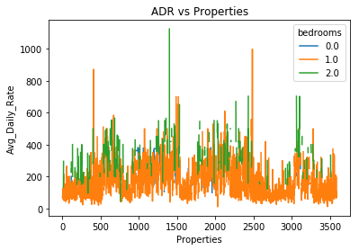

```python
plt.figure(figsize=[8,5])
df_plot = df2.pivot(columns='bedrooms', values='Avg_Daily_Rate')

df_plot.plot()

plt.xlabel('Properties')
plt.ylabel('Avg_Daily_Rate')
plt.title('ADR vs Properties')
plt.show()
```

```python
df2.info()
```

```
<class 'pandas.core.frame.DataFrame'>
Int64Index: 3268 entries, 0 to 3584
Data columns (total 15 columns):
id                  3268 non-null int64
neighbourhood       2751 non-null object
zipcode             3231 non-null object
property_type       3268 non-null object
accommodates        3268 non-null int64
bathrooms           3268 non-null object
bedrooms            3268 non-null object
price               3268 non-null float64
security_deposit    3212 non-null float64
cleaning_fee        3268 non-null float64
availability_30     3268 non-null int64
availability_60     3268 non-null int64
availability_90     3268 non-null int64
availability_365    3268 non-null int64
Avg_Daily_Rate      3268 non-null float64
dtypes: float64(4), int64(6), object(5)
memory usage: 408.5+ KB
```

> The next step is to create and calculate the 'Occupancy Rate' column. This rate will give us an idea of how busy the property is during the month. Ideally, as a rental property owner, we are looking for an Occupancy Rate of around 2. This means that our property rental price is not too low or too high.

> High Occupancy Rates may be a sign that our prices are too low for the area. Low Occupancy Rates may be a sign that our prices are too high for this city. Too high or too low occupancy rates may translate into revenue loss for a rental property.

```python
df2["Occupancy_rate"] = (30 - df2["availability_30"]) / df2["availability_30"]
```

```python
df2.describe()
```

|  | id | accommodates | price | security_deposit | cleaning_fee | availability_30 | availability_60 | availability_90 | availability_365 | Avg_Daily_Rate | Occupancy_rate |
| --- | --- | --- | --- | --- | --- | --- | --- | --- | --- | --- | --- |
| count | 3.268000e+03 | 3268.000000 | 3268.000000 | 3212.000000 | 3268.000000 | 3268.000000 | 3268.000000 | 3268.000000 | 3268.000000 | 3268.000000 | 3268.000000 |
| mean | 8.524883e+06 | 2.782130 | 158.815177 | 88.923101 | 44.030906 | 8.523868 | 21.556916 | 38.107099 | 175.662179 | 202.846083 | inf |
| std | 4.468795e+06 | 1.382792 | 98.148149 | 152.734953 | 49.935238 | 10.476016 | 21.971114 | 33.336908 | 141.991314 | 124.623308 | NaN |
| min | 3.353000e+03 | 1.000000 | 10.000000 | 0.000000 | 0.000000 | 0.000000 | 0.000000 | 0.000000 | 0.000000 | 10.000000 | 0.000000 |
| 25% | 4.818250e+06 | 2.000000 | 81.000000 | 0.000000 | 0.000000 | 0.000000 | 0.000000 | 0.000000 | 17.000000 | 100.000000 | 1.000000 |
| 50% | 8.701923e+06 | 2.000000 | 140.000000 | 0.000000 | 25.000000 | 4.000000 | 14.000000 | 36.000000 | 174.000000 | 178.000000 | 6.500000 |
| 75% | 1.282633e+07 | 4.000000 | 200.000000 | 100.000000 | 75.000000 | 15.000000 | 40.000000 | 68.000000 | 323.000000 | 280.000000 | inf |
| max | 1.493346e+07 | 10.000000 | 999.000000 | 950.000000 | 300.000000 | 30.000000 | 60.000000 | 90.000000 | 365.000000 | 1125.000000 | inf |

```python
df2
```

|  | id | neighbourhood | zipcode | property_type | accommodates | bathrooms | bedrooms | price | security_deposit | cleaning_fee | availability_30 | availability_60 | availability_90 | availability_365 | Avg_Daily_Rate | Occupancy_rate |
| --- | --- | --- | --- | --- | --- | --- | --- | --- | --- | --- | --- | --- | --- | --- | --- | --- |
| 0 | 12147973 | Roslindale | 02131 | House | 4 | 1.5 | 2.0 | 250.0 | 0.0 | 35.0 | 0 | 0 | 0 | 0 | 285.0 | inf |
| 1 | 3075044 | Roslindale | 02131 | Apartment | 2 | 1.0 | 1.0 | 65.0 | 95.0 | 10.0 | 26 | 54 | 84 | 359 | 75.0 | 0.153846 |
| 2 | 6976 | Roslindale | 02131 | Apartment | 2 | 1.0 | 1.0 | 65.0 | 0.0 | 0.0 | 19 | 46 | 61 | 319 | 65.0 | 0.578947 |
| 3 | 1436513 | NaN | NaN | House | 4 | 1.0 | 1.0 | 75.0 | 100.0 | 50.0 | 6 | 16 | 26 | 98 | 125.0 | 4.000000 |
| 4 | 7651065 | Roslindale | 02131 | House | 2 | 1.5 | 1.0 | 79.0 | 0.0 | 15.0 | 13 | 34 | 59 | 334 | 94.0 | 1.307692 |
| 5 | 12386020 | Roslindale | 02131 | Condominium | 2 | 1.0 | 1.0 | 75.0 | 0.0 | 30.0 | 5 | 28 | 58 | 58 | 105.0 | 5.000000 |
| 6 | 5706985 | NaN | 02131 | Apartment | 3 | 1.0 | 1.0 | 100.0 | 0.0 | 0.0 | 22 | 39 | 69 | 344 | 100.0 | 0.363636 |
| 7 | 2843445 | Roslindale | 02131 | House | 2 | 2.0 | 1.0 | 75.0 | 0.0 | 10.0 | 30 | 60 | 90 | 365 | 85.0 | 0.000000 |
| 8 | 753446 | Roslindale | 02131 | Condominium | 2 | 1.0 | 1.0 | 58.0 | 0.0 | 0.0 | 12 | 42 | 72 | 347 | 58.0 | 1.500000 |
| 9 | 849408 | Roslindale | 02131 | Apartment | 5 | 1.0 | 2.0 | 229.0 | 200.0 | 50.0 | 20 | 50 | 80 | 107 | 279.0 | 0.500000 |
| 10 | 12023024 | Roslindale | 02131 | House | 2 | 1.0 | 1.0 | 60.0 | 0.0 | 30.0 | 16 | 38 | 68 | 343 | 90.0 | 0.875000 |
| 11 | 1668313 | Roslindale | 02131 | House | 1 | 1.0 | 1.0 | 57.0 | 0.0 | 40.0 | 6 | 36 | 66 | 341 | 97.0 | 4.000000 |
| 12 | 2684840 | Roslindale | 02131 | Condominium | 4 | 1.0 | 2.0 | 93.0 | 0.0 | 40.0 | 0 | 0 | 0 | 0 | 133.0 | inf |
| 13 | 13547301 | Roslindale | 02131 | Apartment | 5 | 1.0 | 2.0 | 150.0 | 0.0 | 50.0 | 8 | 17 | 39 | 129 | 200.0 | 2.750000 |
| 14 | 5434353 | Roslindale | 02131 | House | 2 | 1.5 | 2.0 | 145.0 | 500.0 | 150.0 | 11 | 14 | 44 | 319 | 295.0 | 1.727273 |
| 15 | 225979 | Roslindale | 02131 | Apartment | 1 | 0.0 | 1.0 | 60.0 | 0.0 | 0.0 | 4 | 34 | 64 | 339 | 60.0 | 6.500000 |
| 16 | 3420384 | Roslindale | 02131 | House | 4 | 1.0 | 1.0 | 165.0 | 0.0 | 50.0 | 20 | 50 | 80 | 349 | 215.0 | 0.500000 |
| 17 | 13512930 | Roslindale | 02131 | Condominium | 2 | 1.0 | 1.0 | 75.0 | 0.0 | 20.0 | 0 | 0 | 0 | 0 | 95.0 | inf |
| 18 | 7482195 | Roslindale | 02131 | House | 1 | 1.0 | 1.0 | 49.0 | 0.0 | 0.0 | 0 | 0 | 20 | 295 | 49.0 | inf |
| 19 | 7252607 | NaN | 02131 | House | 2 | 1.0 | 1.0 | 49.0 | 0.0 | 0.0 | 0 | 0 | 0 | 262 | 49.0 | inf |
| 21 | 13251243 | Roslindale | 02131 | House | 3 | 1.0 | 0.0 | 120.0 | 150.0 | 50.0 | 0 | 7 | 32 | 207 | 170.0 | inf |
| 22 | 225834 | Roslindale | 02131 | Apartment | 2 | 0.0 | 1.0 | 70.0 | 0.0 | 0.0 | 0 | 0 | 24 | 299 | 70.0 | inf |
| 25 | 894539 | Roslindale | 02131 | House | 2 | 1.5 | 1.0 | 95.0 | 0.0 | 10.0 | 0 | 0 | 0 | 1 | 105.0 | inf |
| 26 | 879929 | Roslindale | 02131 | Apartment | 2 | 1.0 | 1.0 | 90.0 | 0.0 | 0.0 | 0 | 0 | 0 | 122 | 90.0 | inf |
| 27 | 9218312 | Roslindale | 02131 | House | 2 | 1.0 | 1.0 | 95.0 | 0.0 | 15.0 | 8 | 16 | 37 | 107 | 110.0 | 2.750000 |
| 28 | 321328 | Roslindale | 02131 | Apartment | 2 | 1.0 | 1.0 | 100.0 | 0.0 | 0.0 | 21 | 51 | 81 | 356 | 100.0 | 0.428571 |
| 29 | 1810172 | Roslindale | 02131 | House | 2 | 1.0 | 1.0 | 67.0 | 0.0 | 40.0 | 0 | 5 | 35 | 310 | 107.0 | inf |
| 30 | 6513924 | Roslindale | 02131 | Condominium | 1 | 1.0 | 1.0 | 55.0 | 0.0 | 0.0 | 0 | 0 | 0 | 129 | 55.0 | inf |
| 31 | 7093109 | Roslindale | 02131 | Apartment | 6 | 1.0 | 2.0 | 200.0 | 200.0 | 85.0 | 21 | 48 | 78 | 353 | 285.0 | 0.428571 |
| 32 | 14690527 | Roslindale | 02131 | Apartment | 4 | 1.0 | 1.0 | 150.0 | 0.0 | 0.0 | 0 | 0 | 3 | 17 | 150.0 | inf |
| ... | ... | ... | ... | ... | ... | ... | ... | ... | ... | ... | ... | ... | ... | ... | ... | ... |
| 3552 | 14773792 | Somerville | 02145 | Apartment | 2 | 1.0 | 1.0 | 47.0 | 0.0 | 25.0 | 24 | 54 | 84 | 359 | 72.0 | 0.250000 |
| 3553 | 14874204 | NaN | 02143 | Apartment | 2 | 1.0 | 1.0 | 69.0 | 95.0 | 0.0 | 25 | 55 | 85 | 360 | 69.0 | 0.200000 |
| 3554 | 14533848 | NaN | 02446 | House | 4 | 1.0 | 1.0 | 125.0 | 0.0 | 25.0 | 0 | 0 | 0 | 5 | 150.0 | inf |
| 3555 | 13015653 | Brookline | 02445 | Apartment | 1 | 1.0 | 1.0 | 39.0 | 100.0 | 20.0 | 3 | 13 | 33 | 226 | 59.0 | 9.000000 |
| 3556 | 14849141 | NaN | 02143 | Apartment | 2 | 1.0 | 1.0 | 69.0 | 0.0 | 0.0 | 26 | 56 | 86 | 361 | 69.0 | 0.153846 |
| 3557 | 14604429 | NaN | NaN | Apartment | 2 | 1.0 | 1.0 | 60.0 | 0.0 | 20.0 | 7 | 7 | 7 | 272 | 80.0 | 3.285714 |
| 3558 | 14592644 | NaN | 02139 | Apartment | 4 | 1.0 | 2.0 | 195.0 | 200.0 | 130.0 | 20 | 45 | 75 | 137 | 325.0 | 0.500000 |
| 3559 | 12915510 | NaN | 02129 | Boat | 7 | 1.0 | 1.0 | 229.0 | 500.0 | 100.0 | 30 | 60 | 90 | 365 | 329.0 | 0.000000 |
| 3561 | 14823430 | NaN | NaN | Loft | 2 | 1.0 | 1.0 | 72.0 | 0.0 | 0.0 | 28 | 58 | 80 | 345 | 72.0 | 0.071429 |
| 3562 | 14881840 | NaN | 02215 | Apartment | 2 | 1.0 | 1.0 | 179.0 | 0.0 | 0.0 | 29 | 59 | 89 | 364 | 179.0 | 0.034483 |
| 3563 | 11452297 | Somerville | 02145 | Apartment | 6 | 2.0 | 2.0 | 199.0 | 200.0 | 0.0 | 0 | 0 | 0 | 63 | 199.0 | inf |
| 3564 | 14576706 | NaN | 02143 | Apartment | 2 | 1.0 | 1.0 | 75.0 | 95.0 | 0.0 | 23 | 53 | 83 | 358 | 75.0 | 0.304348 |
| 3565 | 14335003 | NaN | 02138 | Apartment | 4 | 1.0 | 1.0 | 146.0 | 0.0 | 0.0 | 0 | 0 | 0 | 0 | 146.0 | inf |
| 3566 | 14871445 | Brookline | 02445 | Apartment | 2 | 1.5 | 1.0 | 85.0 | 0.0 | 0.0 | 22 | 52 | 82 | 357 | 85.0 | 0.363636 |
| 3568 | 14574800 | NaN | 02143 | Apartment | 2 | 1.0 | 1.0 | 69.0 | 95.0 | 0.0 | 25 | 55 | 85 | 360 | 69.0 | 0.200000 |
| 3569 | 14426586 | NaN | 02145 | Apartment | 4 | 1.0 | 1.0 | 200.0 | 0.0 | 0.0 | 29 | 59 | 89 | 364 | 200.0 | 0.034483 |
| 3570 | 3131519 | Somerville | 02141 | House | 2 | 1.0 | 1.0 | 72.0 | 100.0 | 20.0 | 12 | 38 | 38 | 38 | 92.0 | 1.500000 |
| 3571 | 14592547 | Brookline | 02446 | Apartment | 2 | 1.0 | 1.0 | 89.0 | 0.0 | 0.0 | 0 | 0 | 0 | 0 | 89.0 | inf |
| 3573 | 14504583 | Somerville | 02145 | Apartment | 2 | 1.0 | 1.0 | 65.0 | 0.0 | 25.0 | 20 | 50 | 80 | 170 | 90.0 | 0.500000 |
| 3574 | 14743129 | Chestnut Hill | 02467 | Townhouse | 1 | 1.0 | 1.0 | 68.0 | 950.0 | 0.0 | 28 | 58 | 88 | 363 | 68.0 | 0.071429 |
| 3575 | 5280827 | Somerville | 02143 | Apartment | 2 | 1.0 | 1.0 | 69.0 | 95.0 | 0.0 | 25 | 51 | 81 | 356 | 69.0 | 0.200000 |
| 3576 | 14689681 | Cambridge | 02139 | House | 2 | 1.0 | 1.0 | 124.0 | 200.0 | 85.0 | 5 | 5 | 20 | 110 | 209.0 | 5.000000 |
| 3577 | 13750763 | Brookline | 02446 | Apartment | 2 | 1.0 | 1.0 | 150.0 | 0.0 | 0.0 | 2 | 9 | 9 | 9 | 150.0 | 14.000000 |
| 3578 | 14536322 | NaN | 02138 | House | 1 | 1.0 | 1.0 | 85.0 | 0.0 | 0.0 | 4 | 16 | 44 | 315 | 85.0 | 6.500000 |
| 3579 | 14852179 | Brookline | 02446 | Condominium | 2 | 1.0 | 1.0 | 100.0 | 0.0 | 10.0 | 0 | 22 | 23 | 23 | 110.0 | inf |
| 3580 | 8373729 | Somerville | 02143 | Apartment | 3 | 1.0 | 1.0 | 69.0 | 95.0 | 0.0 | 21 | 51 | 81 | 356 | 69.0 | 0.428571 |
| 3581 | 14844274 | NaN | 02446 | Apartment | 2 | 1.0 | 1.0 | 150.0 | 100.0 | 15.0 | 29 | 59 | 89 | 364 | 165.0 | 0.034483 |
| 3582 | 14585486 | NaN | 02141 | Apartment | 4 | 1.0 | 1.0 | 198.0 | 0.0 | 0.0 | 0 | 15 | 40 | 40 | 198.0 | inf |
| 3583 | 14603878 | Somerville | 02145 | Apartment | 2 | 1.0 | 1.0 | 65.0 | 100.0 | 0.0 | 5 | 5 | 5 | 253 | 65.0 | 5.000000 |
| 3584 | 14504422 | Somerville | 02145 | Apartment | 2 | 1.0 | 1.0 | 65.0 | 0.0 | 25.0 | 17 | 45 | 75 | 165 | 90.0 | 0.764706 |

3268 rows × 16 columns

> Handling infinite values in the 'Occupancy_rate' column

> I will count them first and then I will drop them for visualization purposes.

```python
df2['Occupancy_rate'].value_counts()
```

```
inf          1254
0.034483      185
0.000000      176
14.000000     143
5.000000      126
9.000000      117
29.000000     113
6.500000      110
4.000000       97
3.285714       80
1.727273       72
2.750000       67
2.000000       62
2.333333       57
1.500000       56
1.307692       45
1.000000       45
1.142857       42
0.764706       42
0.500000       40
0.666667       38
0.153846       38
0.071429       37
0.111111       32
0.250000       32
0.428571       31
0.578947       29
0.304348       28
0.200000       26
0.363636       25
0.875000       23
Name: Occupancy_rate, dtype: int64
```

### Section 5 : Results and result evaluation

##### Occupancy rate

> Here we can see that the dataset contains 1,254 infinite value in the 'Occupancy_rate' column. This means that there are several properties in the Boston area with none or almost none avalability. This also must indicate low rates and eventually loss of revenue for some property owners.

```python
df6 = df2['Occupancy_rate'].replace([np.inf, -np.inf], np.nan).dropna()
```

```python
df6
```

```
1        0.153846
2        0.578947
3        4.000000
4        1.307692
5        5.000000
6        0.363636
7        0.000000
8        1.500000
9        0.500000
10       0.875000
11       4.000000
13       2.750000
14       1.727273
15       6.500000
16       0.500000
```

[output cut: 47 more lines]

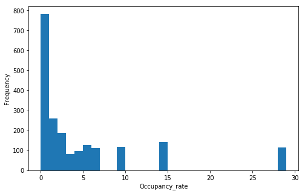

```python
binsize = 1
bins = np.arange(0, df6.max()+binsize, binsize)

# Plotting
plt.figure(figsize=[8, 5])
plt.hist(data = df6, x = df6, bins = bins)

# Labels
plt.xlabel('Occupancy_rate')
plt.ylabel('Frequency')
plt.title('')
plt.show()
```

##### Average Daily Rate

```python
ADR = df2['Avg_Daily_Rate']
```

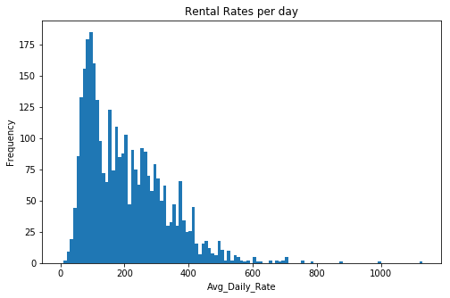

```python
binsize = 10
bins = np.arange(0, df2['Avg_Daily_Rate'].max()+binsize, binsize)

# Plotting
plt.figure(figsize=[8, 5])
plt.hist(data = ADR, x = ADR, bins = bins)

# Labels
plt.xlabel('Avg_Daily_Rate')
plt.ylabel('Frequency')
plt.title('Rental Rates per day')
plt.show()
```

```python
df3=df2.copy()
```

```python
df_house = df3[df3['property_type'].str.contains("House")]
```

> In this section, I will build a simple model by reducing the dataset to only houses and apartments with up to 2 bedrooms and up to 2 bathrooms. In addition to Avg_Daily_Rate and Occupancy_rate columns recently created. This will allow me to analyze the data and continue answering the three questions mentioned at the beggining of this work.

```python
df_house
```

|  | id | neighbourhood | zipcode | property_type | accommodates | bathrooms | bedrooms | price | security_deposit | cleaning_fee | availability_30 | availability_60 | availability_90 | availability_365 | Avg_Daily_Rate | Occupancy_rate |
| --- | --- | --- | --- | --- | --- | --- | --- | --- | --- | --- | --- | --- | --- | --- | --- | --- |
| 0 | 12147973 | Roslindale | 02131 | House | 4 | 1.5 | 2.0 | 250.0 | 0.0 | 35.0 | 0 | 0 | 0 | 0 | 285.0 | inf |
| 3 | 1436513 | NaN | NaN | House | 4 | 1.0 | 1.0 | 75.0 | 100.0 | 50.0 | 6 | 16 | 26 | 98 | 125.0 | 4.000000 |
| 4 | 7651065 | Roslindale | 02131 | House | 2 | 1.5 | 1.0 | 79.0 | 0.0 | 15.0 | 13 | 34 | 59 | 334 | 94.0 | 1.307692 |
| 7 | 2843445 | Roslindale | 02131 | House | 2 | 2.0 | 1.0 | 75.0 | 0.0 | 10.0 | 30 | 60 | 90 | 365 | 85.0 | 0.000000 |
| 10 | 12023024 | Roslindale | 02131 | House | 2 | 1.0 | 1.0 | 60.0 | 0.0 | 30.0 | 16 | 38 | 68 | 343 | 90.0 | 0.875000 |
| 11 | 1668313 | Roslindale | 02131 | House | 1 | 1.0 | 1.0 | 57.0 | 0.0 | 40.0 | 6 | 36 | 66 | 341 | 97.0 | 4.000000 |
| 14 | 5434353 | Roslindale | 02131 | House | 2 | 1.5 | 2.0 | 145.0 | 500.0 | 150.0 | 11 | 14 | 44 | 319 | 295.0 | 1.727273 |
| 16 | 3420384 | Roslindale | 02131 | House | 4 | 1.0 | 1.0 | 165.0 | 0.0 | 50.0 | 20 | 50 | 80 | 349 | 215.0 | 0.500000 |
| 18 | 7482195 | Roslindale | 02131 | House | 1 | 1.0 | 1.0 | 49.0 | 0.0 | 0.0 | 0 | 0 | 20 | 295 | 49.0 | inf |
| 19 | 7252607 | NaN | 02131 | House | 2 | 1.0 | 1.0 | 49.0 | 0.0 | 0.0 | 0 | 0 | 0 | 262 | 49.0 | inf |
| 21 | 13251243 | Roslindale | 02131 | House | 3 | 1.0 | 0.0 | 120.0 | 150.0 | 50.0 | 0 | 7 | 32 | 207 | 170.0 | inf |
| 25 | 894539 | Roslindale | 02131 | House | 2 | 1.5 | 1.0 | 95.0 | 0.0 | 10.0 | 0 | 0 | 0 | 1 | 105.0 | inf |
| 27 | 9218312 | Roslindale | 02131 | House | 2 | 1.0 | 1.0 | 95.0 | 0.0 | 15.0 | 8 | 16 | 37 | 107 | 110.0 | 2.750000 |
| 29 | 1810172 | Roslindale | 02131 | House | 2 | 1.0 | 1.0 | 67.0 | 0.0 | 40.0 | 0 | 5 | 35 | 310 | 107.0 | inf |
| 33 | 7086825 | Roslindale | 02131 | House | 1 | 1.0 | 1.0 | 49.0 | 0.0 | 0.0 | 0 | 20 | 50 | 325 | 49.0 | inf |
| 34 | 1861070 | Roslindale | 02131 | House | 1 | 1.5 | 1.0 | 75.0 | 0.0 | 0.0 | 27 | 57 | 87 | 362 | 75.0 | 0.111111 |
| 35 | 4283698 | Roslindale | 02131 | House | 4 | 1.0 | 1.0 | 110.0 | 0.0 | 25.0 | 7 | 16 | 25 | 300 | 135.0 | 3.285714 |
| 39 | 4085362 | Roslindale | 02131 | House | 2 | 2.0 | 1.0 | 75.0 | 0.0 | 10.0 | 26 | 56 | 86 | 361 | 85.0 | 0.153846 |
| 40 | 3755609 | Roslindale | 02131 | House | 1 | 1.0 | 1.0 | 78.0 | 500.0 | 25.0 | 4 | 34 | 64 | 339 | 103.0 | 6.500000 |
| 43 | 4461111 | Roslindale | 02131 | House | 1 | 1.5 | 1.0 | 45.0 | 0.0 | 0.0 | 6 | 6 | 6 | 254 | 45.0 | 4.000000 |
| 44 | 1724900 | Roslindale | 02131 | House | 4 | 1.0 | 2.0 | 145.0 | 446.0 | 56.0 | 4 | 8 | 38 | 306 | 201.0 | 6.500000 |
| 45 | 13937181 | Roslindale | 02131 | House | 2 | 2.0 | 1.0 | 45.0 | 0.0 | 0.0 | 2 | 28 | 53 | 133 | 45.0 | 14.000000 |
| 46 | 3968797 | Roslindale | 02131 | House | 2 | 1.5 | 1.0 | 85.0 | 0.0 | 10.0 | 0 | 0 | 0 | 267 | 95.0 | inf |
| 47 | 1494726 | Roslindale | 02131 | House | 1 | 1.0 | 1.0 | 75.0 | 200.0 | 50.0 | 20 | 50 | 80 | 355 | 125.0 | 0.500000 |
| 48 | 8473851 | Roslindale | 02131 | House | 2 | 2.0 | 1.0 | 50.0 | 0.0 | 0.0 | 11 | 41 | 71 | 161 | 50.0 | 1.727273 |
| 50 | 1591827 | Roslindale | 02131 | House | 2 | 1.0 | 1.0 | 60.0 | 0.0 | 0.0 | 0 | 0 | 0 | 248 | 60.0 | inf |
| 58 | 2384581 | Jamaica Plain | 02130 | House | 2 | 1.0 | 1.0 | 95.0 | 0.0 | 0.0 | 30 | 60 | 90 | 365 | 95.0 | 0.000000 |
| 61 | 4000384 | Jamaica Plain | 02119 | House | 2 | 1.0 | 1.0 | 120.0 | 0.0 | 0.0 | 7 | 17 | 47 | 109 | 120.0 | 3.285714 |
| 65 | 12806707 | Jamaica Plain | 02130 | House | 1 | 1.0 | 1.0 | 60.0 | 0.0 | 0.0 | 5 | 35 | 65 | 340 | 60.0 | 5.000000 |
| 68 | 4792901 | Jamaica Plain | 02130 | House | 2 | 1.0 | 1.0 | 65.0 | 0.0 | 10.0 | 0 | 0 | 0 | 0 | 75.0 | inf |
| ... | ... | ... | ... | ... | ... | ... | ... | ... | ... | ... | ... | ... | ... | ... | ... | ... |
| 3426 | 4710583 | Allston-Brighton | 02134 | House | 2 | 2.0 | 1.0 | 45.0 | 0.0 | 0.0 | 0 | 0 | 0 | 0 | 45.0 | inf |
| 3427 | 12755021 | Allston-Brighton | 02134 | House | 3 | 1.0 | 1.0 | 65.0 | 0.0 | 0.0 | 0 | 0 | 0 | 0 | 65.0 | inf |
| 3431 | 5858133 | Allston-Brighton | 02134 | House | 2 | 1.0 | 1.0 | 120.0 | 0.0 | 0.0 | 0 | 0 | 0 | 0 | 120.0 | inf |
| 3434 | 9834617 | Allston-Brighton | 02134 | House | 1 | 1.5 | 1.0 | 45.0 | 0.0 | 50.0 | 0 | 0 | 0 | 248 | 95.0 | inf |
| 3436 | 9058863 | Allston-Brighton | 02134 | House | 1 | 1.5 | 1.0 | 50.0 | 0.0 | 50.0 | 30 | 60 | 90 | 365 | 100.0 | 0.000000 |
| 3437 | 7527677 | Allston-Brighton | 02134 | House | 1 | 1.0 | 1.0 | 98.0 | 0.0 | 80.0 | 0 | 0 | 7 | 7 | 178.0 | inf |
| 3446 | 13327034 | Allston-Brighton | 02134 | House | 2 | 2.0 | 1.0 | 80.0 | 100.0 | 35.0 | 0 | 0 | 0 | 257 | 115.0 | inf |
| 3450 | 9854083 | Allston-Brighton | 02134 | House | 1 | 1.5 | 1.0 | 20.0 | 0.0 | 50.0 | 30 | 60 | 90 | 365 | 70.0 | 0.000000 |
| 3451 | 6823017 | Allston-Brighton | 02134 | House | 2 | 2.0 | 1.0 | 70.0 | 100.0 | 35.0 | 3 | 23 | 53 | 328 | 105.0 | 9.000000 |
| 3459 | 9885963 | Allston-Brighton | 02134 | House | 1 | 1.0 | 1.0 | 33.0 | 0.0 | 0.0 | 0 | 0 | 0 | 0 | 33.0 | inf |
| 3472 | 12735138 | Allston-Brighton | 02134 | House | 1 | 2.0 | 1.0 | 45.0 | 250.0 | 50.0 | 0 | 0 | 0 | 0 | 95.0 | inf |
| 3474 | 12735111 | NaN | 02135 | House | 1 | 1.0 | 0.0 | 55.0 | 0.0 | 0.0 | 30 | 58 | 88 | 363 | 55.0 | 0.000000 |
| 3475 | 8034092 | Allston-Brighton | 02134 | House | 1 | 1.5 | 1.0 | 58.0 | 0.0 | 50.0 | 30 | 60 | 90 | 365 | 108.0 | 0.000000 |
| 3492 | 3419711 | Allston-Brighton | 02134 | House | 2 | 2.0 | 1.0 | 70.0 | 0.0 | 10.0 | 5 | 13 | 23 | 298 | 80.0 | 5.000000 |
| 3497 | 1529321 | Allston-Brighton | 02134 | House | 2 | 2.0 | 1.0 | 68.0 | 0.0 | 0.0 | 0 | 0 | 0 | 256 | 68.0 | inf |
| 3499 | 13126713 | Allston-Brighton | 02134 | House | 2 | 2.0 | 1.0 | 130.0 | 0.0 | 50.0 | 28 | 58 | 88 | 363 | 180.0 | 0.071429 |
| 3501 | 1525494 | Allston-Brighton | 02134 | House | 2 | 2.0 | 1.0 | 66.0 | 0.0 | 0.0 | 2 | 9 | 38 | 313 | 66.0 | 14.000000 |
| 3503 | 12176027 | Allston-Brighton | 02134 | House | 2 | 1.0 | 1.0 | 45.0 | 0.0 | 0.0 | 0 | 0 | 0 | 0 | 45.0 | inf |
| 3506 | 6179374 | Allston-Brighton | 02134 | House | 1 | 1.5 | 1.0 | 58.0 | 0.0 | 50.0 | 30 | 60 | 90 | 365 | 108.0 | 0.000000 |
| 3512 | 7783953 | Allston-Brighton | 02134 | House | 2 | 1.0 | 1.0 | 128.0 | 500.0 | 80.0 | 0 | 0 | 7 | 7 | 208.0 | inf |
| 3530 | 11043756 | Allston-Brighton | 02134 | House | 1 | 1.5 | 1.0 | 60.0 | 0.0 | 50.0 | 30 | 60 | 90 | 365 | 110.0 | 0.000000 |
| 3531 | 7462268 | NaN | 02134 | House | 2 | 2.0 | 1.0 | 75.0 | 100.0 | 35.0 | 0 | 11 | 15 | 290 | 110.0 | inf |
| 3533 | 6373729 | Allston-Brighton | 02134 | House | 4 | 1.0 | 1.0 | 75.0 | 200.0 | 35.0 | 0 | 0 | 0 | 0 | 110.0 | inf |
| 3537 | 14503389 | NaN | 02138 | House | 1 | 1.0 | 1.0 | 85.0 | 0.0 | 0.0 | 2 | 18 | 42 | 312 | 85.0 | 14.000000 |
| 3542 | 14902894 | Cambridge | 02139 | House | 4 | 1.0 | 1.0 | 140.0 | 100.0 | 20.0 | 24 | 47 | 77 | 352 | 160.0 | 0.250000 |
| 3546 | 14510982 | Cambridge | 02139 | House | 4 | 1.0 | 2.0 | 240.0 | 0.0 | 60.0 | 30 | 60 | 90 | 180 | 300.0 | 0.000000 |
| 3554 | 14533848 | NaN | 02446 | House | 4 | 1.0 | 1.0 | 125.0 | 0.0 | 25.0 | 0 | 0 | 0 | 5 | 150.0 | inf |
| 3570 | 3131519 | Somerville | 02141 | House | 2 | 1.0 | 1.0 | 72.0 | 100.0 | 20.0 | 12 | 38 | 38 | 38 | 92.0 | 1.500000 |
| 3576 | 14689681 | Cambridge | 02139 | House | 2 | 1.0 | 1.0 | 124.0 | 200.0 | 85.0 | 5 | 5 | 20 | 110 | 209.0 | 5.000000 |
| 3578 | 14536322 | NaN | 02138 | House | 1 | 1.0 | 1.0 | 85.0 | 0.0 | 0.0 | 4 | 16 | 44 | 315 | 85.0 | 6.500000 |

453 rows × 16 columns

```python
del df_house['neighbourhood']
```

```python
del df_house['zipcode']
```

```python
del df_house['property_type']
```

```python
df_house
```

|  | id | accommodates | bathrooms | bedrooms | price | security_deposit | cleaning_fee | availability_30 | availability_60 | availability_90 | availability_365 | Avg_Daily_Rate | Occupancy_rate |
| --- | --- | --- | --- | --- | --- | --- | --- | --- | --- | --- | --- | --- | --- |
| 0 | 12147973 | 4 | 1.5 | 2.0 | 250.0 | 0.0 | 35.0 | 0 | 0 | 0 | 0 | 285.0 | inf |
| 3 | 1436513 | 4 | 1.0 | 1.0 | 75.0 | 100.0 | 50.0 | 6 | 16 | 26 | 98 | 125.0 | 4.000000 |
| 4 | 7651065 | 2 | 1.5 | 1.0 | 79.0 | 0.0 | 15.0 | 13 | 34 | 59 | 334 | 94.0 | 1.307692 |
| 7 | 2843445 | 2 | 2.0 | 1.0 | 75.0 | 0.0 | 10.0 | 30 | 60 | 90 | 365 | 85.0 | 0.000000 |
| 10 | 12023024 | 2 | 1.0 | 1.0 | 60.0 | 0.0 | 30.0 | 16 | 38 | 68 | 343 | 90.0 | 0.875000 |
| 11 | 1668313 | 1 | 1.0 | 1.0 | 57.0 | 0.0 | 40.0 | 6 | 36 | 66 | 341 | 97.0 | 4.000000 |
| 14 | 5434353 | 2 | 1.5 | 2.0 | 145.0 | 500.0 | 150.0 | 11 | 14 | 44 | 319 | 295.0 | 1.727273 |
| 16 | 3420384 | 4 | 1.0 | 1.0 | 165.0 | 0.0 | 50.0 | 20 | 50 | 80 | 349 | 215.0 | 0.500000 |
| 18 | 7482195 | 1 | 1.0 | 1.0 | 49.0 | 0.0 | 0.0 | 0 | 0 | 20 | 295 | 49.0 | inf |
| 19 | 7252607 | 2 | 1.0 | 1.0 | 49.0 | 0.0 | 0.0 | 0 | 0 | 0 | 262 | 49.0 | inf |
| 21 | 13251243 | 3 | 1.0 | 0.0 | 120.0 | 150.0 | 50.0 | 0 | 7 | 32 | 207 | 170.0 | inf |
| 25 | 894539 | 2 | 1.5 | 1.0 | 95.0 | 0.0 | 10.0 | 0 | 0 | 0 | 1 | 105.0 | inf |
| 27 | 9218312 | 2 | 1.0 | 1.0 | 95.0 | 0.0 | 15.0 | 8 | 16 | 37 | 107 | 110.0 | 2.750000 |
| 29 | 1810172 | 2 | 1.0 | 1.0 | 67.0 | 0.0 | 40.0 | 0 | 5 | 35 | 310 | 107.0 | inf |
| 33 | 7086825 | 1 | 1.0 | 1.0 | 49.0 | 0.0 | 0.0 | 0 | 20 | 50 | 325 | 49.0 | inf |
| 34 | 1861070 | 1 | 1.5 | 1.0 | 75.0 | 0.0 | 0.0 | 27 | 57 | 87 | 362 | 75.0 | 0.111111 |
| 35 | 4283698 | 4 | 1.0 | 1.0 | 110.0 | 0.0 | 25.0 | 7 | 16 | 25 | 300 | 135.0 | 3.285714 |
| 39 | 4085362 | 2 | 2.0 | 1.0 | 75.0 | 0.0 | 10.0 | 26 | 56 | 86 | 361 | 85.0 | 0.153846 |
| 40 | 3755609 | 1 | 1.0 | 1.0 | 78.0 | 500.0 | 25.0 | 4 | 34 | 64 | 339 | 103.0 | 6.500000 |
| 43 | 4461111 | 1 | 1.5 | 1.0 | 45.0 | 0.0 | 0.0 | 6 | 6 | 6 | 254 | 45.0 | 4.000000 |
| 44 | 1724900 | 4 | 1.0 | 2.0 | 145.0 | 446.0 | 56.0 | 4 | 8 | 38 | 306 | 201.0 | 6.500000 |
| 45 | 13937181 | 2 | 2.0 | 1.0 | 45.0 | 0.0 | 0.0 | 2 | 28 | 53 | 133 | 45.0 | 14.000000 |
| 46 | 3968797 | 2 | 1.5 | 1.0 | 85.0 | 0.0 | 10.0 | 0 | 0 | 0 | 267 | 95.0 | inf |
| 47 | 1494726 | 1 | 1.0 | 1.0 | 75.0 | 200.0 | 50.0 | 20 | 50 | 80 | 355 | 125.0 | 0.500000 |
| 48 | 8473851 | 2 | 2.0 | 1.0 | 50.0 | 0.0 | 0.0 | 11 | 41 | 71 | 161 | 50.0 | 1.727273 |
| 50 | 1591827 | 2 | 1.0 | 1.0 | 60.0 | 0.0 | 0.0 | 0 | 0 | 0 | 248 | 60.0 | inf |
| 58 | 2384581 | 2 | 1.0 | 1.0 | 95.0 | 0.0 | 0.0 | 30 | 60 | 90 | 365 | 95.0 | 0.000000 |
| 61 | 4000384 | 2 | 1.0 | 1.0 | 120.0 | 0.0 | 0.0 | 7 | 17 | 47 | 109 | 120.0 | 3.285714 |
| 65 | 12806707 | 1 | 1.0 | 1.0 | 60.0 | 0.0 | 0.0 | 5 | 35 | 65 | 340 | 60.0 | 5.000000 |
| 68 | 4792901 | 2 | 1.0 | 1.0 | 65.0 | 0.0 | 10.0 | 0 | 0 | 0 | 0 | 75.0 | inf |
| ... | ... | ... | ... | ... | ... | ... | ... | ... | ... | ... | ... | ... | ... |
| 3426 | 4710583 | 2 | 2.0 | 1.0 | 45.0 | 0.0 | 0.0 | 0 | 0 | 0 | 0 | 45.0 | inf |
| 3427 | 12755021 | 3 | 1.0 | 1.0 | 65.0 | 0.0 | 0.0 | 0 | 0 | 0 | 0 | 65.0 | inf |
| 3431 | 5858133 | 2 | 1.0 | 1.0 | 120.0 | 0.0 | 0.0 | 0 | 0 | 0 | 0 | 120.0 | inf |
| 3434 | 9834617 | 1 | 1.5 | 1.0 | 45.0 | 0.0 | 50.0 | 0 | 0 | 0 | 248 | 95.0 | inf |
| 3436 | 9058863 | 1 | 1.5 | 1.0 | 50.0 | 0.0 | 50.0 | 30 | 60 | 90 | 365 | 100.0 | 0.000000 |
| 3437 | 7527677 | 1 | 1.0 | 1.0 | 98.0 | 0.0 | 80.0 | 0 | 0 | 7 | 7 | 178.0 | inf |
| 3446 | 13327034 | 2 | 2.0 | 1.0 | 80.0 | 100.0 | 35.0 | 0 | 0 | 0 | 257 | 115.0 | inf |
| 3450 | 9854083 | 1 | 1.5 | 1.0 | 20.0 | 0.0 | 50.0 | 30 | 60 | 90 | 365 | 70.0 | 0.000000 |
| 3451 | 6823017 | 2 | 2.0 | 1.0 | 70.0 | 100.0 | 35.0 | 3 | 23 | 53 | 328 | 105.0 | 9.000000 |
| 3459 | 9885963 | 1 | 1.0 | 1.0 | 33.0 | 0.0 | 0.0 | 0 | 0 | 0 | 0 | 33.0 | inf |
| 3472 | 12735138 | 1 | 2.0 | 1.0 | 45.0 | 250.0 | 50.0 | 0 | 0 | 0 | 0 | 95.0 | inf |
| 3474 | 12735111 | 1 | 1.0 | 0.0 | 55.0 | 0.0 | 0.0 | 30 | 58 | 88 | 363 | 55.0 | 0.000000 |
| 3475 | 8034092 | 1 | 1.5 | 1.0 | 58.0 | 0.0 | 50.0 | 30 | 60 | 90 | 365 | 108.0 | 0.000000 |
| 3492 | 3419711 | 2 | 2.0 | 1.0 | 70.0 | 0.0 | 10.0 | 5 | 13 | 23 | 298 | 80.0 | 5.000000 |
| 3497 | 1529321 | 2 | 2.0 | 1.0 | 68.0 | 0.0 | 0.0 | 0 | 0 | 0 | 256 | 68.0 | inf |
| 3499 | 13126713 | 2 | 2.0 | 1.0 | 130.0 | 0.0 | 50.0 | 28 | 58 | 88 | 363 | 180.0 | 0.071429 |
| 3501 | 1525494 | 2 | 2.0 | 1.0 | 66.0 | 0.0 | 0.0 | 2 | 9 | 38 | 313 | 66.0 | 14.000000 |
| 3503 | 12176027 | 2 | 1.0 | 1.0 | 45.0 | 0.0 | 0.0 | 0 | 0 | 0 | 0 | 45.0 | inf |
| 3506 | 6179374 | 1 | 1.5 | 1.0 | 58.0 | 0.0 | 50.0 | 30 | 60 | 90 | 365 | 108.0 | 0.000000 |
| 3512 | 7783953 | 2 | 1.0 | 1.0 | 128.0 | 500.0 | 80.0 | 0 | 0 | 7 | 7 | 208.0 | inf |
| 3530 | 11043756 | 1 | 1.5 | 1.0 | 60.0 | 0.0 | 50.0 | 30 | 60 | 90 | 365 | 110.0 | 0.000000 |
| 3531 | 7462268 | 2 | 2.0 | 1.0 | 75.0 | 100.0 | 35.0 | 0 | 11 | 15 | 290 | 110.0 | inf |
| 3533 | 6373729 | 4 | 1.0 | 1.0 | 75.0 | 200.0 | 35.0 | 0 | 0 | 0 | 0 | 110.0 | inf |
| 3537 | 14503389 | 1 | 1.0 | 1.0 | 85.0 | 0.0 | 0.0 | 2 | 18 | 42 | 312 | 85.0 | 14.000000 |
| 3542 | 14902894 | 4 | 1.0 | 1.0 | 140.0 | 100.0 | 20.0 | 24 | 47 | 77 | 352 | 160.0 | 0.250000 |
| 3546 | 14510982 | 4 | 1.0 | 2.0 | 240.0 | 0.0 | 60.0 | 30 | 60 | 90 | 180 | 300.0 | 0.000000 |
| 3554 | 14533848 | 4 | 1.0 | 1.0 | 125.0 | 0.0 | 25.0 | 0 | 0 | 0 | 5 | 150.0 | inf |
| 3570 | 3131519 | 2 | 1.0 | 1.0 | 72.0 | 100.0 | 20.0 | 12 | 38 | 38 | 38 | 92.0 | 1.500000 |
| 3576 | 14689681 | 2 | 1.0 | 1.0 | 124.0 | 200.0 | 85.0 | 5 | 5 | 20 | 110 | 209.0 | 5.000000 |
| 3578 | 14536322 | 1 | 1.0 | 1.0 | 85.0 | 0.0 | 0.0 | 4 | 16 | 44 | 315 | 85.0 | 6.500000 |

453 rows × 13 columns

```python
df_house.info()
```

```
<class 'pandas.core.frame.DataFrame'>
Int64Index: 453 entries, 0 to 3578
Data columns (total 13 columns):
id                  453 non-null int64
accommodates        453 non-null int64
bathrooms           453 non-null object
bedrooms            453 non-null object
price               453 non-null float64
security_deposit    448 non-null float64
cleaning_fee        453 non-null float64
availability_30     453 non-null int64
availability_60     453 non-null int64
availability_90     453 non-null int64
availability_365    453 non-null int64
Avg_Daily_Rate      453 non-null float64
Occupancy_rate      453 non-null float64
dtypes: float64(5), int64(6), object(2)
memory usage: 49.5+ KB
```

```python
df_apartment = df3[df3['property_type'].str.contains("Apartment")]
```

```python
df_apartment
```

|  | id | neighbourhood | zipcode | property_type | accommodates | bathrooms | bedrooms | price | security_deposit | cleaning_fee | availability_30 | availability_60 | availability_90 | availability_365 | Avg_Daily_Rate | Occupancy_rate |
| --- | --- | --- | --- | --- | --- | --- | --- | --- | --- | --- | --- | --- | --- | --- | --- | --- |
| 1 | 3075044 | Roslindale | 02131 | Apartment | 2 | 1.0 | 1.0 | 65.0 | 95.0 | 10.0 | 26 | 54 | 84 | 359 | 75.0 | 0.153846 |
| 2 | 6976 | Roslindale | 02131 | Apartment | 2 | 1.0 | 1.0 | 65.0 | 0.0 | 0.0 | 19 | 46 | 61 | 319 | 65.0 | 0.578947 |
| 6 | 5706985 | NaN | 02131 | Apartment | 3 | 1.0 | 1.0 | 100.0 | 0.0 | 0.0 | 22 | 39 | 69 | 344 | 100.0 | 0.363636 |
| 9 | 849408 | Roslindale | 02131 | Apartment | 5 | 1.0 | 2.0 | 229.0 | 200.0 | 50.0 | 20 | 50 | 80 | 107 | 279.0 | 0.500000 |
| 13 | 13547301 | Roslindale | 02131 | Apartment | 5 | 1.0 | 2.0 | 150.0 | 0.0 | 50.0 | 8 | 17 | 39 | 129 | 200.0 | 2.750000 |
| 15 | 225979 | Roslindale | 02131 | Apartment | 1 | 0.0 | 1.0 | 60.0 | 0.0 | 0.0 | 4 | 34 | 64 | 339 | 60.0 | 6.500000 |
| 22 | 225834 | Roslindale | 02131 | Apartment | 2 | 0.0 | 1.0 | 70.0 | 0.0 | 0.0 | 0 | 0 | 24 | 299 | 70.0 | inf |
| 26 | 879929 | Roslindale | 02131 | Apartment | 2 | 1.0 | 1.0 | 90.0 | 0.0 | 0.0 | 0 | 0 | 0 | 122 | 90.0 | inf |
| 28 | 321328 | Roslindale | 02131 | Apartment | 2 | 1.0 | 1.0 | 100.0 | 0.0 | 0.0 | 21 | 51 | 81 | 356 | 100.0 | 0.428571 |
| 31 | 7093109 | Roslindale | 02131 | Apartment | 6 | 1.0 | 2.0 | 200.0 | 200.0 | 85.0 | 21 | 48 | 78 | 353 | 285.0 | 0.428571 |
| 32 | 14690527 | Roslindale | 02131 | Apartment | 4 | 1.0 | 1.0 | 150.0 | 0.0 | 0.0 | 0 | 0 | 3 | 17 | 150.0 | inf |
| 36 | 10116095 | NaN | 02131 | Apartment | 2 | 1.0 | 1.0 | 115.0 | 200.0 | 35.0 | 19 | 46 | 76 | 351 | 150.0 | 0.578947 |
| 41 | 13768853 | Roslindale | 02131 | Apartment | 4 | 1.0 | 1.0 | 50.0 | 0.0 | 10.0 | 0 | 0 | 0 | 0 | 60.0 | inf |
| 42 | 1936861 | Roslindale | 02131 | Apartment | 1 | 1.0 | 1.0 | 60.0 | 0.0 | 0.0 | 20 | 50 | 80 | 355 | 60.0 | 0.500000 |
| 51 | 3229255 | Roslindale | 02131 | Apartment | 3 | 1.0 | 1.0 | 95.0 | 250.0 | 35.0 | 8 | 20 | 46 | 258 | 130.0 | 2.750000 |
| 52 | 1721016 | Roslindale | 02131 | Apartment | 2 | 1.0 | 0.0 | 89.0 | 223.0 | 45.0 | 19 | 43 | 73 | 348 | 134.0 | 0.578947 |
| 53 | 12535687 | Roslindale | 02131 | Apartment | 3 | 1.0 | 0.0 | 110.0 | 0.0 | 25.0 | 17 | 40 | 58 | 333 | 135.0 | 0.764706 |
| 56 | 169938 | Jamaica Plain | 02130 | Apartment | 4 | 1.0 | 1.0 | 140.0 | 0.0 | 125.0 | 17 | 24 | 54 | 144 | 265.0 | 0.764706 |
| 57 | 594693 | Jamaica Plain | 02130 | Apartment | 2 | 1.0 | 1.0 | 70.0 | 0.0 | 10.0 | 3 | 23 | 53 | 328 | 80.0 | 9.000000 |
| 60 | 4262255 | Jamaica Plain | 02130 | Apartment | 2 | 1.0 | 1.0 | 80.0 | 0.0 | 0.0 | 0 | 8 | 26 | 301 | 80.0 | inf |
| 62 | 6693305 | Jamaica Plain | 02130 | Apartment | 2 | 1.0 | 1.0 | 65.0 | 0.0 | 0.0 | 0 | 0 | 0 | 0 | 65.0 | inf |
| 63 | 6730758 | Jamaica Plain | 02130 | Apartment | 4 | 1.0 | 1.0 | 100.0 | 0.0 | 0.0 | 1 | 3 | 3 | 23 | 100.0 | 29.000000 |
| 64 | 6248970 | NaN | 02130 | Apartment | 1 | 1.0 | 1.0 | 65.0 | 0.0 | 0.0 | 7 | 13 | 43 | 43 | 65.0 | 3.285714 |
| 66 | 14246616 | Jamaica Plain | 02130 | Apartment | 2 | 1.0 | 1.0 | 63.0 | 0.0 | 0.0 | 0 | 0 | 0 | 0 | 63.0 | inf |
| 69 | 5717528 | Jamaica Plain | 02130 | Apartment | 1 | 1.0 | 1.0 | 110.0 | 0.0 | 0.0 | 11 | 41 | 71 | 346 | 110.0 | 1.727273 |
| 71 | 13333862 | Jamaica Plain | 02130 | Apartment | 3 | 1.0 | 1.0 | 75.0 | 300.0 | 50.0 | 0 | 0 | 0 | 0 | 125.0 | inf |
| 72 | 519272 | Jamaica Plain | 02130 | Apartment | 2 | 1.5 | 1.0 | 62.0 | 150.0 | 25.0 | 0 | 0 | 0 | 0 | 87.0 | inf |
| 74 | 8481291 | Jamaica Plain | 02130 | Apartment | 2 | 1.0 | 1.0 | 69.0 | 0.0 | 20.0 | 0 | 0 | 0 | 0 | 89.0 | inf |
| 76 | 197727 | Jamaica Plain | 02130 | Apartment | 1 | 1.0 | 1.0 | 85.0 | 0.0 | 0.0 | 0 | 1 | 31 | 306 | 85.0 | inf |
| 77 | 932853 | Jamaica Plain | 02130 | Apartment | 2 | 2.0 | 1.0 | 120.0 | 500.0 | 80.0 | 4 | 32 | 62 | 337 | 200.0 | 6.500000 |
| ... | ... | ... | ... | ... | ... | ... | ... | ... | ... | ... | ... | ... | ... | ... | ... | ... |
| 3539 | 4332035 | NaN | 02446 | Apartment | 3 | 1.0 | 1.0 | 272.0 | 0.0 | 100.0 | 6 | 36 | 66 | 124 | 372.0 | 4.000000 |
| 3540 | 9807292 | Brookline | 02446 | Apartment | 5 | 2.0 | 2.0 | 350.0 | 0.0 | 100.0 | 22 | 52 | 82 | 140 | 450.0 | 0.363636 |
| 3543 | 14866400 | Somerville | 02145 | Apartment | 1 | 2.0 | 1.0 | 70.0 | 0.0 | 0.0 | 0 | 0 | 4 | 279 | 70.0 | inf |
| 3544 | 14584547 | Cambridge | 02138 | Apartment | 4 | 1.0 | 2.0 | 295.0 | 500.0 | 200.0 | 29 | 59 | 89 | 364 | 495.0 | 0.034483 |
| 3547 | 14848154 | NaN | 02145 | Apartment | 3 | 1.0 | 1.0 | 88.0 | 95.0 | 0.0 | 28 | 55 | 85 | 360 | 88.0 | 0.071429 |
| 3549 | 14487346 | Somerville | 02145 | Apartment | 2 | 1.0 | 1.0 | 80.0 | 500.0 | 100.0 | 6 | 36 | 66 | 341 | 180.0 | 4.000000 |
| 3550 | 14550228 | Cambridge | 02139 | Apartment | 2 | 1.0 | 1.0 | 113.0 | 0.0 | 230.0 | 30 | 60 | 90 | 90 | 343.0 | 0.000000 |
| 3551 | 14566657 | Cambridge | 02141 | Apartment | 3 | 1.0 | 1.0 | 180.0 | 0.0 | 0.0 | 8 | 30 | 57 | 329 | 180.0 | 2.750000 |
| 3552 | 14773792 | Somerville | 02145 | Apartment | 2 | 1.0 | 1.0 | 47.0 | 0.0 | 25.0 | 24 | 54 | 84 | 359 | 72.0 | 0.250000 |
| 3553 | 14874204 | NaN | 02143 | Apartment | 2 | 1.0 | 1.0 | 69.0 | 95.0 | 0.0 | 25 | 55 | 85 | 360 | 69.0 | 0.200000 |
| 3555 | 13015653 | Brookline | 02445 | Apartment | 1 | 1.0 | 1.0 | 39.0 | 100.0 | 20.0 | 3 | 13 | 33 | 226 | 59.0 | 9.000000 |
| 3556 | 14849141 | NaN | 02143 | Apartment | 2 | 1.0 | 1.0 | 69.0 | 0.0 | 0.0 | 26 | 56 | 86 | 361 | 69.0 | 0.153846 |
| 3557 | 14604429 | NaN | NaN | Apartment | 2 | 1.0 | 1.0 | 60.0 | 0.0 | 20.0 | 7 | 7 | 7 | 272 | 80.0 | 3.285714 |
| 3558 | 14592644 | NaN | 02139 | Apartment | 4 | 1.0 | 2.0 | 195.0 | 200.0 | 130.0 | 20 | 45 | 75 | 137 | 325.0 | 0.500000 |
| 3562 | 14881840 | NaN | 02215 | Apartment | 2 | 1.0 | 1.0 | 179.0 | 0.0 | 0.0 | 29 | 59 | 89 | 364 | 179.0 | 0.034483 |
| 3563 | 11452297 | Somerville | 02145 | Apartment | 6 | 2.0 | 2.0 | 199.0 | 200.0 | 0.0 | 0 | 0 | 0 | 63 | 199.0 | inf |
| 3564 | 14576706 | NaN | 02143 | Apartment | 2 | 1.0 | 1.0 | 75.0 | 95.0 | 0.0 | 23 | 53 | 83 | 358 | 75.0 | 0.304348 |
| 3565 | 14335003 | NaN | 02138 | Apartment | 4 | 1.0 | 1.0 | 146.0 | 0.0 | 0.0 | 0 | 0 | 0 | 0 | 146.0 | inf |
| 3566 | 14871445 | Brookline | 02445 | Apartment | 2 | 1.5 | 1.0 | 85.0 | 0.0 | 0.0 | 22 | 52 | 82 | 357 | 85.0 | 0.363636 |
| 3568 | 14574800 | NaN | 02143 | Apartment | 2 | 1.0 | 1.0 | 69.0 | 95.0 | 0.0 | 25 | 55 | 85 | 360 | 69.0 | 0.200000 |
| 3569 | 14426586 | NaN | 02145 | Apartment | 4 | 1.0 | 1.0 | 200.0 | 0.0 | 0.0 | 29 | 59 | 89 | 364 | 200.0 | 0.034483 |
| 3571 | 14592547 | Brookline | 02446 | Apartment | 2 | 1.0 | 1.0 | 89.0 | 0.0 | 0.0 | 0 | 0 | 0 | 0 | 89.0 | inf |
| 3573 | 14504583 | Somerville | 02145 | Apartment | 2 | 1.0 | 1.0 | 65.0 | 0.0 | 25.0 | 20 | 50 | 80 | 170 | 90.0 | 0.500000 |
| 3575 | 5280827 | Somerville | 02143 | Apartment | 2 | 1.0 | 1.0 | 69.0 | 95.0 | 0.0 | 25 | 51 | 81 | 356 | 69.0 | 0.200000 |
| 3577 | 13750763 | Brookline | 02446 | Apartment | 2 | 1.0 | 1.0 | 150.0 | 0.0 | 0.0 | 2 | 9 | 9 | 9 | 150.0 | 14.000000 |
| 3580 | 8373729 | Somerville | 02143 | Apartment | 3 | 1.0 | 1.0 | 69.0 | 95.0 | 0.0 | 21 | 51 | 81 | 356 | 69.0 | 0.428571 |
| 3581 | 14844274 | NaN | 02446 | Apartment | 2 | 1.0 | 1.0 | 150.0 | 100.0 | 15.0 | 29 | 59 | 89 | 364 | 165.0 | 0.034483 |
| 3582 | 14585486 | NaN | 02141 | Apartment | 4 | 1.0 | 1.0 | 198.0 | 0.0 | 0.0 | 0 | 15 | 40 | 40 | 198.0 | inf |
| 3583 | 14603878 | Somerville | 02145 | Apartment | 2 | 1.0 | 1.0 | 65.0 | 100.0 | 0.0 | 5 | 5 | 5 | 253 | 65.0 | 5.000000 |
| 3584 | 14504422 | Somerville | 02145 | Apartment | 2 | 1.0 | 1.0 | 65.0 | 0.0 | 25.0 | 17 | 45 | 75 | 165 | 90.0 | 0.764706 |

2443 rows × 16 columns

```python
del df_apartment['neighbourhood']
```

```python
del df_apartment['zipcode']
```

```python
del df_apartment['property_type']
```

```python
df_apartment
```

|  | id | accommodates | bathrooms | bedrooms | price | security_deposit | cleaning_fee | availability_30 | availability_60 | availability_90 | availability_365 | Avg_Daily_Rate | Occupancy_rate |
| --- | --- | --- | --- | --- | --- | --- | --- | --- | --- | --- | --- | --- | --- |
| 1 | 3075044 | 2 | 1.0 | 1.0 | 65.0 | 95.0 | 10.0 | 26 | 54 | 84 | 359 | 75.0 | 0.153846 |
| 2 | 6976 | 2 | 1.0 | 1.0 | 65.0 | 0.0 | 0.0 | 19 | 46 | 61 | 319 | 65.0 | 0.578947 |
| 6 | 5706985 | 3 | 1.0 | 1.0 | 100.0 | 0.0 | 0.0 | 22 | 39 | 69 | 344 | 100.0 | 0.363636 |
| 9 | 849408 | 5 | 1.0 | 2.0 | 229.0 | 200.0 | 50.0 | 20 | 50 | 80 | 107 | 279.0 | 0.500000 |
| 13 | 13547301 | 5 | 1.0 | 2.0 | 150.0 | 0.0 | 50.0 | 8 | 17 | 39 | 129 | 200.0 | 2.750000 |
| 15 | 225979 | 1 | 0.0 | 1.0 | 60.0 | 0.0 | 0.0 | 4 | 34 | 64 | 339 | 60.0 | 6.500000 |
| 22 | 225834 | 2 | 0.0 | 1.0 | 70.0 | 0.0 | 0.0 | 0 | 0 | 24 | 299 | 70.0 | inf |
| 26 | 879929 | 2 | 1.0 | 1.0 | 90.0 | 0.0 | 0.0 | 0 | 0 | 0 | 122 | 90.0 | inf |
| 28 | 321328 | 2 | 1.0 | 1.0 | 100.0 | 0.0 | 0.0 | 21 | 51 | 81 | 356 | 100.0 | 0.428571 |
| 31 | 7093109 | 6 | 1.0 | 2.0 | 200.0 | 200.0 | 85.0 | 21 | 48 | 78 | 353 | 285.0 | 0.428571 |
| 32 | 14690527 | 4 | 1.0 | 1.0 | 150.0 | 0.0 | 0.0 | 0 | 0 | 3 | 17 | 150.0 | inf |
| 36 | 10116095 | 2 | 1.0 | 1.0 | 115.0 | 200.0 | 35.0 | 19 | 46 | 76 | 351 | 150.0 | 0.578947 |
| 41 | 13768853 | 4 | 1.0 | 1.0 | 50.0 | 0.0 | 10.0 | 0 | 0 | 0 | 0 | 60.0 | inf |
| 42 | 1936861 | 1 | 1.0 | 1.0 | 60.0 | 0.0 | 0.0 | 20 | 50 | 80 | 355 | 60.0 | 0.500000 |
| 51 | 3229255 | 3 | 1.0 | 1.0 | 95.0 | 250.0 | 35.0 | 8 | 20 | 46 | 258 | 130.0 | 2.750000 |
| 52 | 1721016 | 2 | 1.0 | 0.0 | 89.0 | 223.0 | 45.0 | 19 | 43 | 73 | 348 | 134.0 | 0.578947 |
| 53 | 12535687 | 3 | 1.0 | 0.0 | 110.0 | 0.0 | 25.0 | 17 | 40 | 58 | 333 | 135.0 | 0.764706 |
| 56 | 169938 | 4 | 1.0 | 1.0 | 140.0 | 0.0 | 125.0 | 17 | 24 | 54 | 144 | 265.0 | 0.764706 |
| 57 | 594693 | 2 | 1.0 | 1.0 | 70.0 | 0.0 | 10.0 | 3 | 23 | 53 | 328 | 80.0 | 9.000000 |
| 60 | 4262255 | 2 | 1.0 | 1.0 | 80.0 | 0.0 | 0.0 | 0 | 8 | 26 | 301 | 80.0 | inf |
| 62 | 6693305 | 2 | 1.0 | 1.0 | 65.0 | 0.0 | 0.0 | 0 | 0 | 0 | 0 | 65.0 | inf |
| 63 | 6730758 | 4 | 1.0 | 1.0 | 100.0 | 0.0 | 0.0 | 1 | 3 | 3 | 23 | 100.0 | 29.000000 |
| 64 | 6248970 | 1 | 1.0 | 1.0 | 65.0 | 0.0 | 0.0 | 7 | 13 | 43 | 43 | 65.0 | 3.285714 |
| 66 | 14246616 | 2 | 1.0 | 1.0 | 63.0 | 0.0 | 0.0 | 0 | 0 | 0 | 0 | 63.0 | inf |
| 69 | 5717528 | 1 | 1.0 | 1.0 | 110.0 | 0.0 | 0.0 | 11 | 41 | 71 | 346 | 110.0 | 1.727273 |
| 71 | 13333862 | 3 | 1.0 | 1.0 | 75.0 | 300.0 | 50.0 | 0 | 0 | 0 | 0 | 125.0 | inf |
| 72 | 519272 | 2 | 1.5 | 1.0 | 62.0 | 150.0 | 25.0 | 0 | 0 | 0 | 0 | 87.0 | inf |
| 74 | 8481291 | 2 | 1.0 | 1.0 | 69.0 | 0.0 | 20.0 | 0 | 0 | 0 | 0 | 89.0 | inf |
| 76 | 197727 | 1 | 1.0 | 1.0 | 85.0 | 0.0 | 0.0 | 0 | 1 | 31 | 306 | 85.0 | inf |
| 77 | 932853 | 2 | 2.0 | 1.0 | 120.0 | 500.0 | 80.0 | 4 | 32 | 62 | 337 | 200.0 | 6.500000 |
| ... | ... | ... | ... | ... | ... | ... | ... | ... | ... | ... | ... | ... | ... |
| 3539 | 4332035 | 3 | 1.0 | 1.0 | 272.0 | 0.0 | 100.0 | 6 | 36 | 66 | 124 | 372.0 | 4.000000 |
| 3540 | 9807292 | 5 | 2.0 | 2.0 | 350.0 | 0.0 | 100.0 | 22 | 52 | 82 | 140 | 450.0 | 0.363636 |
| 3543 | 14866400 | 1 | 2.0 | 1.0 | 70.0 | 0.0 | 0.0 | 0 | 0 | 4 | 279 | 70.0 | inf |
| 3544 | 14584547 | 4 | 1.0 | 2.0 | 295.0 | 500.0 | 200.0 | 29 | 59 | 89 | 364 | 495.0 | 0.034483 |
| 3547 | 14848154 | 3 | 1.0 | 1.0 | 88.0 | 95.0 | 0.0 | 28 | 55 | 85 | 360 | 88.0 | 0.071429 |
| 3549 | 14487346 | 2 | 1.0 | 1.0 | 80.0 | 500.0 | 100.0 | 6 | 36 | 66 | 341 | 180.0 | 4.000000 |
| 3550 | 14550228 | 2 | 1.0 | 1.0 | 113.0 | 0.0 | 230.0 | 30 | 60 | 90 | 90 | 343.0 | 0.000000 |
| 3551 | 14566657 | 3 | 1.0 | 1.0 | 180.0 | 0.0 | 0.0 | 8 | 30 | 57 | 329 | 180.0 | 2.750000 |
| 3552 | 14773792 | 2 | 1.0 | 1.0 | 47.0 | 0.0 | 25.0 | 24 | 54 | 84 | 359 | 72.0 | 0.250000 |
| 3553 | 14874204 | 2 | 1.0 | 1.0 | 69.0 | 95.0 | 0.0 | 25 | 55 | 85 | 360 | 69.0 | 0.200000 |
| 3555 | 13015653 | 1 | 1.0 | 1.0 | 39.0 | 100.0 | 20.0 | 3 | 13 | 33 | 226 | 59.0 | 9.000000 |
| 3556 | 14849141 | 2 | 1.0 | 1.0 | 69.0 | 0.0 | 0.0 | 26 | 56 | 86 | 361 | 69.0 | 0.153846 |
| 3557 | 14604429 | 2 | 1.0 | 1.0 | 60.0 | 0.0 | 20.0 | 7 | 7 | 7 | 272 | 80.0 | 3.285714 |
| 3558 | 14592644 | 4 | 1.0 | 2.0 | 195.0 | 200.0 | 130.0 | 20 | 45 | 75 | 137 | 325.0 | 0.500000 |
| 3562 | 14881840 | 2 | 1.0 | 1.0 | 179.0 | 0.0 | 0.0 | 29 | 59 | 89 | 364 | 179.0 | 0.034483 |
| 3563 | 11452297 | 6 | 2.0 | 2.0 | 199.0 | 200.0 | 0.0 | 0 | 0 | 0 | 63 | 199.0 | inf |
| 3564 | 14576706 | 2 | 1.0 | 1.0 | 75.0 | 95.0 | 0.0 | 23 | 53 | 83 | 358 | 75.0 | 0.304348 |
| 3565 | 14335003 | 4 | 1.0 | 1.0 | 146.0 | 0.0 | 0.0 | 0 | 0 | 0 | 0 | 146.0 | inf |
| 3566 | 14871445 | 2 | 1.5 | 1.0 | 85.0 | 0.0 | 0.0 | 22 | 52 | 82 | 357 | 85.0 | 0.363636 |
| 3568 | 14574800 | 2 | 1.0 | 1.0 | 69.0 | 95.0 | 0.0 | 25 | 55 | 85 | 360 | 69.0 | 0.200000 |
| 3569 | 14426586 | 4 | 1.0 | 1.0 | 200.0 | 0.0 | 0.0 | 29 | 59 | 89 | 364 | 200.0 | 0.034483 |
| 3571 | 14592547 | 2 | 1.0 | 1.0 | 89.0 | 0.0 | 0.0 | 0 | 0 | 0 | 0 | 89.0 | inf |
| 3573 | 14504583 | 2 | 1.0 | 1.0 | 65.0 | 0.0 | 25.0 | 20 | 50 | 80 | 170 | 90.0 | 0.500000 |
| 3575 | 5280827 | 2 | 1.0 | 1.0 | 69.0 | 95.0 | 0.0 | 25 | 51 | 81 | 356 | 69.0 | 0.200000 |
| 3577 | 13750763 | 2 | 1.0 | 1.0 | 150.0 | 0.0 | 0.0 | 2 | 9 | 9 | 9 | 150.0 | 14.000000 |
| 3580 | 8373729 | 3 | 1.0 | 1.0 | 69.0 | 95.0 | 0.0 | 21 | 51 | 81 | 356 | 69.0 | 0.428571 |
| 3581 | 14844274 | 2 | 1.0 | 1.0 | 150.0 | 100.0 | 15.0 | 29 | 59 | 89 | 364 | 165.0 | 0.034483 |
| 3582 | 14585486 | 4 | 1.0 | 1.0 | 198.0 | 0.0 | 0.0 | 0 | 15 | 40 | 40 | 198.0 | inf |
| 3583 | 14603878 | 2 | 1.0 | 1.0 | 65.0 | 100.0 | 0.0 | 5 | 5 | 5 | 253 | 65.0 | 5.000000 |
| 3584 | 14504422 | 2 | 1.0 | 1.0 | 65.0 | 0.0 | 25.0 | 17 | 45 | 75 | 165 | 90.0 | 0.764706 |

2443 rows × 13 columns

##### Linear regression and r-squared values

> In this section, I will use a linear regression model with categorial and dummy variables and calculate r-squared values to see if this model can be exapanded to a more sophisticated model with more variable. Ideally this basic model can be expanded to predict the rental price for investor who want to buy small properties in the Boston area.

> Initially, the model will use categorical variables: bathrooms and bedrooms

```python
#Split into explanatory and response variables

X = df_house[['bathrooms','bedrooms']]
y = df_house['price']
```

```python
X_train, X_test, y_train, y_test = train_test_split(X, y, test_size = .30, random_state = 42)

lm_model = LinearRegression(normalize = True)
lm_model.fit(X_train, y_train)
```

```
LinearRegression(copy_X=True, fit_intercept=True, n_jobs=1, normalize=True)
```

```python
y_test_preds = lm_model.predict(X_test)
"The r-squared score for the model using only bathrooms and bedrooms as categorical variables was {} on {} values.".format(r2_score(y_test, y_test_preds), len(y_test))
```

```
'The r-squared score for the model using only bathrooms and bedrooms as categorical variables was 0.3263924840487844 on 136 values.'
```

> The r-squared score is 0.33. Now, I will use dummy variables to see if the model gets better for testing and training.

> First, I will identify the object variables, the I will use dummy variables in the model.

```python
cat_df = df_house.select_dtypes(include=['object'])
```

```python
cat_df.shape[1]
```

```
2
```

```python
print(cat_df)
```

```
     bathrooms bedrooms
0          1.5      2.0
3          1.0      1.0
4          1.5      1.0
7          2.0      1.0
10         1.0      1.0
11         1.0      1.0
14         1.5      2.0
16         1.0      1.0
18         1.0      1.0
19         1.0      1.0
21         1.0      0.0
25         1.5      1.0
27         1.0      1.0
29         1.0      1.0
```

[output cut: 49 more lines]

```python
dummy_cols_df = pd.get_dummies(df_house['bathrooms'], dummy_na=False)
```

```python
dummy_cols_df
```

|  | 0.5 | 1.0 | 1.5 | 2.0 |
| --- | --- | --- | --- | --- |
| 0 | 0 | 0 | 1 | 0 |
| 3 | 0 | 1 | 0 | 0 |
| 4 | 0 | 0 | 1 | 0 |
| 7 | 0 | 0 | 0 | 1 |
| 10 | 0 | 1 | 0 | 0 |
| 11 | 0 | 1 | 0 | 0 |
| 14 | 0 | 0 | 1 | 0 |
| 16 | 0 | 1 | 0 | 0 |
| 18 | 0 | 1 | 0 | 0 |
| 19 | 0 | 1 | 0 | 0 |
| 21 | 0 | 1 | 0 | 0 |
| 25 | 0 | 0 | 1 | 0 |
| 27 | 0 | 1 | 0 | 0 |
| 29 | 0 | 1 | 0 | 0 |
| 33 | 0 | 1 | 0 | 0 |
| 34 | 0 | 0 | 1 | 0 |
| 35 | 0 | 1 | 0 | 0 |
| 39 | 0 | 0 | 0 | 1 |
| 40 | 0 | 1 | 0 | 0 |
| 43 | 0 | 0 | 1 | 0 |
| 44 | 0 | 1 | 0 | 0 |
| 45 | 0 | 0 | 0 | 1 |
| 46 | 0 | 0 | 1 | 0 |
| 47 | 0 | 1 | 0 | 0 |
| 48 | 0 | 0 | 0 | 1 |
| 50 | 0 | 1 | 0 | 0 |
| 58 | 0 | 1 | 0 | 0 |
| 61 | 0 | 1 | 0 | 0 |
| 65 | 0 | 1 | 0 | 0 |
| 68 | 0 | 1 | 0 | 0 |
| ... | ... | ... | ... | ... |
| 3426 | 0 | 0 | 0 | 1 |
| 3427 | 0 | 1 | 0 | 0 |
| 3431 | 0 | 1 | 0 | 0 |
| 3434 | 0 | 0 | 1 | 0 |
| 3436 | 0 | 0 | 1 | 0 |
| 3437 | 0 | 1 | 0 | 0 |
| 3446 | 0 | 0 | 0 | 1 |
| 3450 | 0 | 0 | 1 | 0 |
| 3451 | 0 | 0 | 0 | 1 |
| 3459 | 0 | 1 | 0 | 0 |
| 3472 | 0 | 0 | 0 | 1 |
| 3474 | 0 | 1 | 0 | 0 |
| 3475 | 0 | 0 | 1 | 0 |
| 3492 | 0 | 0 | 0 | 1 |
| 3497 | 0 | 0 | 0 | 1 |
| 3499 | 0 | 0 | 0 | 1 |
| 3501 | 0 | 0 | 0 | 1 |
| 3503 | 0 | 1 | 0 | 0 |
| 3506 | 0 | 0 | 1 | 0 |
| 3512 | 0 | 1 | 0 | 0 |
| 3530 | 0 | 0 | 1 | 0 |
| 3531 | 0 | 0 | 0 | 1 |
| 3533 | 0 | 1 | 0 | 0 |
| 3537 | 0 | 1 | 0 | 0 |
| 3542 | 0 | 1 | 0 | 0 |
| 3546 | 0 | 1 | 0 | 0 |
| 3554 | 0 | 1 | 0 | 0 |
| 3570 | 0 | 1 | 0 | 0 |
| 3576 | 0 | 1 | 0 | 0 |
| 3578 | 0 | 1 | 0 | 0 |

453 rows × 4 columns

```python
dummy_cols_df = pd.get_dummies(df_house['bedrooms'], dummy_na=False)
```

```python
dummy_cols_df
```

|  | 0.0 | 1.0 | 2.0 |
| --- | --- | --- | --- |
| 0 | 0 | 0 | 1 |
| 3 | 0 | 1 | 0 |
| 4 | 0 | 1 | 0 |
| 7 | 0 | 1 | 0 |
| 10 | 0 | 1 | 0 |
| 11 | 0 | 1 | 0 |
| 14 | 0 | 0 | 1 |
| 16 | 0 | 1 | 0 |
| 18 | 0 | 1 | 0 |
| 19 | 0 | 1 | 0 |
| 21 | 1 | 0 | 0 |
| 25 | 0 | 1 | 0 |
| 27 | 0 | 1 | 0 |
| 29 | 0 | 1 | 0 |
| 33 | 0 | 1 | 0 |
| 34 | 0 | 1 | 0 |
| 35 | 0 | 1 | 0 |
| 39 | 0 | 1 | 0 |
| 40 | 0 | 1 | 0 |
| 43 | 0 | 1 | 0 |
| 44 | 0 | 0 | 1 |
| 45 | 0 | 1 | 0 |
| 46 | 0 | 1 | 0 |
| 47 | 0 | 1 | 0 |
| 48 | 0 | 1 | 0 |
| 50 | 0 | 1 | 0 |
| 58 | 0 | 1 | 0 |
| 61 | 0 | 1 | 0 |
| 65 | 0 | 1 | 0 |
| 68 | 0 | 1 | 0 |
| ... | ... | ... | ... |
| 3426 | 0 | 1 | 0 |
| 3427 | 0 | 1 | 0 |
| 3431 | 0 | 1 | 0 |
| 3434 | 0 | 1 | 0 |
| 3436 | 0 | 1 | 0 |
| 3437 | 0 | 1 | 0 |
| 3446 | 0 | 1 | 0 |
| 3450 | 0 | 1 | 0 |
| 3451 | 0 | 1 | 0 |
| 3459 | 0 | 1 | 0 |
| 3472 | 0 | 1 | 0 |
| 3474 | 1 | 0 | 0 |
| 3475 | 0 | 1 | 0 |
| 3492 | 0 | 1 | 0 |
| 3497 | 0 | 1 | 0 |
| 3499 | 0 | 1 | 0 |
| 3501 | 0 | 1 | 0 |
| 3503 | 0 | 1 | 0 |
| 3506 | 0 | 1 | 0 |
| 3512 | 0 | 1 | 0 |
| 3530 | 0 | 1 | 0 |
| 3531 | 0 | 1 | 0 |
| 3533 | 0 | 1 | 0 |
| 3537 | 0 | 1 | 0 |
| 3542 | 0 | 1 | 0 |
| 3546 | 0 | 0 | 1 |
| 3554 | 0 | 1 | 0 |
| 3570 | 0 | 1 | 0 |
| 3576 | 0 | 1 | 0 |
| 3578 | 0 | 1 | 0 |

453 rows × 3 columns

```python
# The following function replaces a categorical column with several dummy columns that contain the categorical values.

def create_dummy_df(df, cat_cols, dummy_na):
    for col in cat_cols:
        try:
            df = pd.concat([df.drop(col, axis=1), pd.get_dummies(df[col], prefix=col, prefix_sep='_', drop_first=False, dummy_na=dummy_na)], axis=1)
        except:
            continue
        return df
```

```python
# Identify the categorical columns in the dataset

cat_df = df_house.select_dtypes(include=['object'])
```

```python
cat_cols_lst = cat_df.columns
```

```python
# Here the function takes the 'bathrooms' column and creates 4 bathrooms dummy columns with its respective values

df_new = create_dummy_df(df_house, cat_cols_lst, dummy_na = False)
```

```python
df_new.head()
```

|  | id | accommodates | bedrooms | price | security_deposit | cleaning_fee | availability_30 | availability_60 | availability_90 | availability_365 | Avg_Daily_Rate | Occupancy_rate | bathrooms_0.5 | bathrooms_1.0 | bathrooms_1.5 | bathrooms_2.0 |
| --- | --- | --- | --- | --- | --- | --- | --- | --- | --- | --- | --- | --- | --- | --- | --- | --- |
| 0 | 12147973 | 4 | 2.0 | 250.0 | 0.0 | 35.0 | 0 | 0 | 0 | 0 | 285.0 | inf | 0 | 0 | 1 | 0 |
| 3 | 1436513 | 4 | 1.0 | 75.0 | 100.0 | 50.0 | 6 | 16 | 26 | 98 | 125.0 | 4.000000 | 0 | 1 | 0 | 0 |
| 4 | 7651065 | 2 | 1.0 | 79.0 | 0.0 | 15.0 | 13 | 34 | 59 | 334 | 94.0 | 1.307692 | 0 | 0 | 1 | 0 |
| 7 | 2843445 | 2 | 1.0 | 75.0 | 0.0 | 10.0 | 30 | 60 | 90 | 365 | 85.0 | 0.000000 | 0 | 0 | 0 | 1 |
| 10 | 12023024 | 2 | 1.0 | 60.0 | 0.0 | 30.0 | 16 | 38 | 68 | 343 | 90.0 | 0.875000 | 0 | 1 | 0 | 0 |

```python
df_new2 = create_dummy_df(df_new, cat_cols_lst, dummy_na = False)
```

```python
df_new2.head()
```

|  | id | accommodates | price | security_deposit | cleaning_fee | availability_30 | availability_60 | availability_90 | availability_365 | Avg_Daily_Rate | Occupancy_rate | bathrooms_0.5 | bathrooms_1.0 | bathrooms_1.5 | bathrooms_2.0 | bedrooms_0.0 | bedrooms_1.0 | bedrooms_2.0 |
| --- | --- | --- | --- | --- | --- | --- | --- | --- | --- | --- | --- | --- | --- | --- | --- | --- | --- | --- |
| 0 | 12147973 | 4 | 250.0 | 0.0 | 35.0 | 0 | 0 | 0 | 0 | 285.0 | inf | 0 | 0 | 1 | 0 | 0 | 0 | 1 |
| 3 | 1436513 | 4 | 75.0 | 100.0 | 50.0 | 6 | 16 | 26 | 98 | 125.0 | 4.000000 | 0 | 1 | 0 | 0 | 0 | 1 | 0 |
| 4 | 7651065 | 2 | 79.0 | 0.0 | 15.0 | 13 | 34 | 59 | 334 | 94.0 | 1.307692 | 0 | 0 | 1 | 0 | 0 | 1 | 0 |
| 7 | 2843445 | 2 | 75.0 | 0.0 | 10.0 | 30 | 60 | 90 | 365 | 85.0 | 0.000000 | 0 | 0 | 0 | 1 | 0 | 1 | 0 |
| 10 | 12023024 | 2 | 60.0 | 0.0 | 30.0 | 16 | 38 | 68 | 343 | 90.0 | 0.875000 | 0 | 1 | 0 | 0 | 0 | 1 | 0 |

```python
#Split into explanatory and response variables

X = df_new2[['bathrooms_0.5','bathrooms_1.0','bathrooms_1.5','bathrooms_2.0','bedrooms_0.0','bedrooms_1.0','bedrooms_2.0']]
y = df_new2['price']
```

```python
X_train, X_test, y_train, y_test = train_test_split(X, y, test_size = .30, random_state = 42)

lm_model = LinearRegression(normalize = True)
lm_model.fit(X_train, y_train)
```

```
LinearRegression(copy_X=True, fit_intercept=True, n_jobs=1, normalize=True)
```

```python
y_test_preds = lm_model.predict(X_test)
"The r-squared score for the model using dummy variables was {} on {} values.".format(r2_score(y_test, y_test_preds), len(y_test))
```

```
'The r-squared score for the model using dummy variables was 0.40209472026881654 on 136 values.'
```

> In the house dataset, we can see that the r-squared value of the regression model improved for 0.33 to 0.4, This means that by using dummy variables for bedrooms and badrooms we will help to obtain a better prediction for the rental prices for small properties.

##### Rental prices analysis

> This is simplified model, in reality the predictor of a rental price consider many more variables, but this could be the initial point for a more complex model.

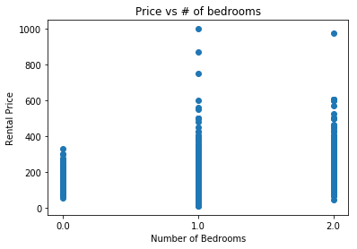

```python
plt.scatter(df_apartment['bedrooms'], df_apartment['price'])

plt.xlabel('Number of Bedrooms')
plt.ylabel('Rental Price')
plt.title('Price vs # of bedrooms')
plt.show()
```

> Here we can observe that there is not a big difference in rental price between a property with 1 bedroom vs a property with 2 bedrooms.

[figure not shown]

```python
plt.scatter(df_apartment['bathrooms'], df_apartment['price'])

plt.xlabel('Number of Bathrooms')
plt.ylabel('Rental Price')
plt.title('Price vs # of bathrooms')
plt.show()
```

> In this chart, we can observe that the number of bathrooms will make a bigger difference in the rental price for properties in the Boston area.

```python
def clean_fit_linear_mod(df, response_col, cat_cols, dummy_na, test_size=.3, rand_state=42):
    df = df.dropna(subset=[response_col], axis=0)
    df = df.dropna(how='all', axis=1)
    df = create_dummy_df(df_new2, cat_cols, dummy_na)
    #fill_mean=lambda col:col.fillna(col.mean())
    #df = df.apply(fill_mean, axis=0)
    #X= df.drop(response_col, axis=1)
    #y= df[response_col]

    #Split into train and test variables
    X_train, X_test, y_train, y_test = train_test_split(X, y, test_size = test_size, random_state = rand_state)

    lm_model = LinearRegression(normalize = True) #Instantiate
    lm_model.fit(X_train, y_train) #Fit

    y_test_preds = lm_model.predict(X_test)
    y_train_preds = lm_model.predict(X_train)

    test_score = r2_score(y_test, y_test_preds)
    train_score = r2_score(y_train, y_train_preds)

    return test_score, train_score, lm_model, X_train, X_test, y_train, y_test
```

```python
clean_fit_linear_mod(df_new2, 'price', cat_cols_lst, dummy_na = False)
```

```
(0.40209472026881654,
 0.37379314296732724,
 LinearRegression(copy_X=True, fit_intercept=True, n_jobs=1, normalize=True),
       bathrooms_0.5  bathrooms_1.0  bathrooms_1.5  bathrooms_2.0  \
 3379              0              0              1              0
 483               0              1              0              0
 2728              0              1              0              0
 3426              0              0              0              1
 666               0              1              0              0
 508               0              0              0              1
 1624              0              1              0              0
 1680              0              0              1              0
 2962              0              1              0              0
 3331              0              1              0              0
 3094              0              1              0              0
```

[output cut: 366 more lines]

```python
df_new2['price'].mean()
```

```
96.496688741721854
```

```python
test_score, train_score, lm_model, X_train, X_test, y_train, y_test = clean_fit_linear_mod(df_new, 'price', cat_cols_lst, dummy_na=False)
```

```python
print("The r-squared score on the training data was {}. The r_squared on the test data was {}.".format(train_score, test_score))
```

```
The r-squared score on the training data was 0.37379314296732724. The r_squared on the test data was 0.40209472026881654.
```

> I will do a similar analysis for the apartments dataset

```python
#Split into explanatory and response variables

X = df_apartment[['bathrooms','bedrooms']]
y = df_apartment['price']
```

```python
X_train, X_test, y_train, y_test = train_test_split(X, y, test_size = .30, random_state = 42)

lm_model = LinearRegression(normalize = True)
lm_model.fit(X_train, y_train)
```

```
LinearRegression(copy_X=True, fit_intercept=True, n_jobs=1, normalize=True)
```

```python
y_test_preds = lm_model.predict(X_test)
"The r-squared score for the model using only quantitative variables was {} on {} values.".format(r2_score(y_test, y_test_preds), len(y_test))
```

```
'The r-squared score for the model using only quantitative variables was 0.159664114060858 on 733 values.'
```

> In the case of apartments by using only categorical variables for bedrooms and bathrooms, we have a r-squared value of 0.16.

```python
cat_df2 = df_apartment.select_dtypes(include=['object'])
```

```python
cat_df2.shape[1]
```

```
2
```

```python
print(cat_df2)
```

```
     bathrooms bedrooms
1          1.0      1.0
2          1.0      1.0
6          1.0      1.0
9          1.0      2.0
13         1.0      2.0
15         0.0      1.0
22         0.0      1.0
26         1.0      1.0
28         1.0      1.0
31         1.0      2.0
32         1.0      1.0
36         1.0      1.0
41         1.0      1.0
42         1.0      1.0
```

[output cut: 49 more lines]

```python
df_new3 = create_dummy_df(df_apartment, cat_cols_lst, dummy_na = False)
```

```python
df_new3.head()
```

|  | id | accommodates | bedrooms | price | security_deposit | cleaning_fee | availability_30 | availability_60 | availability_90 | availability_365 | Avg_Daily_Rate | Occupancy_rate | bathrooms_0.0 | bathrooms_0.5 | bathrooms_1.0 | bathrooms_1.5 | bathrooms_2.0 |
| --- | --- | --- | --- | --- | --- | --- | --- | --- | --- | --- | --- | --- | --- | --- | --- | --- | --- |
| 1 | 3075044 | 2 | 1.0 | 65.0 | 95.0 | 10.0 | 26 | 54 | 84 | 359 | 75.0 | 0.153846 | 0 | 0 | 1 | 0 | 0 |
| 2 | 6976 | 2 | 1.0 | 65.0 | 0.0 | 0.0 | 19 | 46 | 61 | 319 | 65.0 | 0.578947 | 0 | 0 | 1 | 0 | 0 |
| 6 | 5706985 | 3 | 1.0 | 100.0 | 0.0 | 0.0 | 22 | 39 | 69 | 344 | 100.0 | 0.363636 | 0 | 0 | 1 | 0 | 0 |
| 9 | 849408 | 5 | 2.0 | 229.0 | 200.0 | 50.0 | 20 | 50 | 80 | 107 | 279.0 | 0.500000 | 0 | 0 | 1 | 0 | 0 |
| 13 | 13547301 | 5 | 2.0 | 150.0 | 0.0 | 50.0 | 8 | 17 | 39 | 129 | 200.0 | 2.750000 | 0 | 0 | 1 | 0 | 0 |

```python
df_new4 = create_dummy_df(df_new3, cat_cols_lst, dummy_na = False)
```

```python
df_new4.head()
```

|  | id | accommodates | price | security_deposit | cleaning_fee | availability_30 | availability_60 | availability_90 | availability_365 | Avg_Daily_Rate | Occupancy_rate | bathrooms_0.0 | bathrooms_0.5 | bathrooms_1.0 | bathrooms_1.5 | bathrooms_2.0 | bedrooms_0.0 | bedrooms_1.0 | bedrooms_2.0 |
| --- | --- | --- | --- | --- | --- | --- | --- | --- | --- | --- | --- | --- | --- | --- | --- | --- | --- | --- | --- |
| 1 | 3075044 | 2 | 65.0 | 95.0 | 10.0 | 26 | 54 | 84 | 359 | 75.0 | 0.153846 | 0 | 0 | 1 | 0 | 0 | 0 | 1 | 0 |
| 2 | 6976 | 2 | 65.0 | 0.0 | 0.0 | 19 | 46 | 61 | 319 | 65.0 | 0.578947 | 0 | 0 | 1 | 0 | 0 | 0 | 1 | 0 |
| 6 | 5706985 | 3 | 100.0 | 0.0 | 0.0 | 22 | 39 | 69 | 344 | 100.0 | 0.363636 | 0 | 0 | 1 | 0 | 0 | 0 | 1 | 0 |
| 9 | 849408 | 5 | 229.0 | 200.0 | 50.0 | 20 | 50 | 80 | 107 | 279.0 | 0.500000 | 0 | 0 | 1 | 0 | 0 | 0 | 0 | 1 |
| 13 | 13547301 | 5 | 150.0 | 0.0 | 50.0 | 8 | 17 | 39 | 129 | 200.0 | 2.750000 | 0 | 0 | 1 | 0 | 0 | 0 | 0 | 1 |

```python
#Split into explanatory and response variables

X = df_new4[['bathrooms_0.0','bathrooms_0.5','bathrooms_1.0','bathrooms_1.5','bathrooms_2.0','bedrooms_0.0','bedrooms_1.0','bedrooms_2.0']]
y = df_new4['price']
```

```python
clean_fit_linear_mod(df_new4, 'price', cat_cols_lst, dummy_na = False)
```

```
(0.21387290726474806,
 0.23301537988460952,
 LinearRegression(copy_X=True, fit_intercept=True, n_jobs=1, normalize=True),
       bathrooms_0.0  bathrooms_0.5  bathrooms_1.0  bathrooms_1.5  \
 1177              0              0              1              0
 422               0              0              1              0
 2612              0              0              1              0
 2320              0              0              1              0
 1226              0              0              1              0
 338               0              0              1              0
 2796              0              0              1              0
 868               0              0              1              0
 1869              0              0              1              0
 493               0              0              0              0
 826               0              0              1              0
```

[output cut: 366 more lines]

```python
test_score, train_score, lm_model, X_train, X_test, y_train, y_test = clean_fit_linear_mod(df_new4, 'price', cat_cols_lst, dummy_na=False)
```

```python
print("The r-squared score on the training data was {}. The r_squared on the test data was {}.".format(train_score, test_score))
```

```
The r-squared score on the training data was 0.23301537988460952. The r_squared on the test data was 0.21387290726474806.
```

> Here we can observe that the r-squared value using dummy variables increase from 0.16 to 0.23 for training data and 0.21 for test data. Again, replacing categorical variables is better for building a more complex model to predict rental prices.

```python
df_new4['price'].mean()
```

```
168.16864510847319
```